# Manuscript figures and tables

## Shared analysis functions

**Show shared statistical and plotting helpers used by the analyses below**

```
import os
import warnings

import numpy as np
import pandas as pd
import scipy.stats as sps
import matplotlib
matplotlib.use("Agg")
import matplotlib.pyplot as plt
from lifelines import KaplanMeierFitter, CoxPHFitter
from lifelines.statistics import logrank_test

warnings.filterwarnings("ignore")

BASE          = os.path.dirname(os.path.dirname(os.path.abspath(__file__)))
OUT_DIR       = os.path.join(BASE, "manuscript_final_code", "outputs")
os.makedirs(OUT_DIR, exist_ok=True)

DAYS_PER_MONTH = 30.44
ID_COLS = ["Bundling.ID", "GalaxyID"]


def fmt_p(p):
    if p is None or (isinstance(p, float) and np.isnan(p)):
        return ""
    return "<0.001" if p < 0.001 else f"{p:.3f}"


def hide_spines(ax):
    for s in ("top", "right"):
        ax.spines[s].set_visible(False)


def simplify_stage(s):
    if pd.isna(s):
        return np.nan
    s = str(s).strip()
    if s.startswith("IV") or s == "Mts/Rec":
        return 4
    if s.startswith("III"):
        return 3
    if s.startswith("II"):
        return 2
    if s.startswith("I"):
        return 1
    return np.nan


def stage_dummies(stage_series, prefix="stage"):
    STAGE_I_MERGE_MIN = 10
    s_num = pd.to_numeric(stage_series, errors="coerce")
    if 0 < int((s_num == 1).sum()) < STAGE_I_MERGE_MIN:
        stage_series = s_num.replace({1: 2})
    s = stage_series.dropna().astype(int)
    if s.nunique() < 2:
        return pd.DataFrame(index=stage_series.index)
    dd = pd.get_dummies(stage_series.astype("Int64"), prefix=prefix).astype(float)
    ref_col = sorted(dd.columns, key=lambda c: int(c.split("_")[-1]))[0]
    return dd.drop(columns=[ref_col])


def _pt_grp(x):
    s = str(x)
    if s.startswith("pT4"):
        return "T4"
    for k in ("pT1", "pT2", "pT3"):
        if s.startswith(k):
            return k[1:]
    return np.nan


def _pn_grp(x):
    s = str(x)
    for k in ("pN0", "pN1", "pN2"):
        if s.startswith(k):
            return k[1:]
    return np.nan


def _lvi(x):
    if pd.isna(x):
        return np.nan
    s = str(x)
    return "Present" if ("Ly1" in s or "V1" in s) else "Absent"


def _pni(x):
    if pd.isna(x):
        return np.nan
    s = str(x)
    if s.startswith("Pn1"):
        return "Present"
    if s.startswith("Pn0"):
        return "Absent"
    return np.nan


def derive_baseline(m, mtm_col):
    m = m.copy()
    m["age"] = pd.to_numeric(m["Age"], errors="coerce")
    m["age_grp"] = pd.cut(m["age"], [-np.inf, 65, 75, np.inf],
                          labels=["<65", "65\u201374", "\u226575"], right=False)
    m["sex"] = m["Sex"]
    ecog_n = pd.to_numeric(m["ECOG"], errors="coerce")
    m["ecog"] = np.where(ecog_n >= 1, "\u22651", "0")
    m.loc[ecog_n.isna(), "ecog"] = np.nan
    m["stage"] = m["stage_num"].map({1: "I", 2: "II", 3: "III", 4: "IV"})
    m["pT_grp"] = m["pT"].apply(_pt_grp)
    m["pN_grp"] = m["pN"].apply(_pn_grp)
    m["sidedness"] = m["LocationGrpA"].replace("Unknown", np.nan)
    m["primary"]   = m["LocationGrpB"]
    m["msi"]  = m["msi_call"].map({"MSS": "MSS", "MSI-High": "MSI-H"})
    m["ras"]  = m["ras_call"].map({"WT": "Negative", "MUT": "Positive"})
    m["braf"] = m["braf_call"].map({"WT": "Negative", "MUT": "Positive"})
    m["lvi"] = m["p_LVI"].apply(_lvi)
    m["pni"] = m["p_PNI"].apply(_pni)
    m["mrd"] = np.where(m["mrd_pos"], "Positive", "Negative")
    mtm = pd.to_numeric(m[mtm_col], errors="coerce")
    m["mrd_mtm_pos"] = np.where(m["mrd_pos"], mtm, np.nan)
    m["fu_months"] = pd.to_numeric(m["p_drelOS"], errors="coerce") / DAYS_PER_MONTH
    m["os_evt"] = pd.to_numeric(m["p_evtOS"], errors="coerce")
    return m


def _cont_p(samples):
    samples = [x for x in samples if len(x) > 0]
    if len(samples) < 2:
        return np.nan
    try:
        if len(samples) == 2:
            return sps.mannwhitneyu(samples[0], samples[1], alternative="two-sided").pvalue
        return sps.kruskal(*samples).pvalue
    except Exception:
        return np.nan


def _cat_p(tab):
    if tab.shape[0] < 2 or tab.shape[1] < 2 or tab.values.sum() == 0:
        return np.nan
    try:
        if tab.shape == (2, 2):
            return sps.fisher_exact(tab.values)[1]
        return sps.chi2_contingency(tab.values)[1]
    except Exception:
        return np.nan


def _cont_stat(sr, dec=0):
    sr = sr.dropna()
    if sr.empty:
        return ""
    return f"{sr.median():.{dec}f} [{sr.quantile(.25):.{dec}f}\u2013{sr.quantile(.75):.{dec}f}]"


def _cont_row(rows, cols, groups, label, col, dec=0, show_p=True):
    r = {"Characteristic": label}
    for name, gdf in cols:
        r[name] = _cont_stat(gdf[col], dec)
    r["p"] = fmt_p(_cont_p([gdf[col].dropna().values for gdf in groups])) if show_p else "\u2013"
    rows.append(r)


def _cat_rows(rows, cols, groups, label, col, order, show_missing=True):
    rows.append({"Characteristic": label, **{c[0]: "" for c in cols}, "p": ""})
    header_idx = len(rows) - 1
    for lv in order:
        r = {"Characteristic": f"  {lv}"}
        for name, gdf in cols:
            n_tot = len(gdf)
            n_lv = int((gdf[col] == lv).sum())
            r[name] = f"{n_lv} ({100*n_lv/n_tot:.1f}%)" if n_tot else "0"
        r["p"] = ""
        rows.append(r)
    tab = pd.DataFrame({i: groups[i][col].value_counts() for i in range(len(groups))}).fillna(0)
    tab = tab.loc[[lv for lv in order if lv in tab.index]]
    rows[header_idx]["p"] = fmt_p(_cat_p(tab))
    if show_missing:
        r = {"Characteristic": "  Missing"}
        for name, gdf in cols:
            n_tot = len(gdf)
            n_miss = int(gdf[col].isna().sum())
            r[name] = f"{n_miss} ({100*n_miss/n_tot:.1f}%)" if n_tot else "0"
        r["p"] = ""
        rows.append(r)


def build_demographics_table(cols, groups, include_mrd_row):
    rows = []
    rows.append({"Characteristic": "N", **{name: f"{len(gdf):,}" for name, gdf in cols}, "p": ""})
    _cont_row(rows, cols, groups, "Follow-up time in months, median [IQR]", "fu_months", dec=1, show_p=False)
    if include_mrd_row:
        _cat_rows(rows, cols, groups, "MRD-window ctDNA status", "mrd",
                  order=["Negative", "Positive"], show_missing=False)
    _cont_row(rows, cols, groups, "Age, median [IQR], y", "age")
    _cat_rows(rows, cols, groups, "Age group", "age_grp",
              order=["<65", "65\u201374", "\u226575"], show_missing=False)
    _cat_rows(rows, cols, groups, "Sex", "sex", order=["Female", "Male"], show_missing=False)
    _cat_rows(rows, cols, groups, "ECOG performance status", "ecog", order=["0", "\u22651"])
    _cat_rows(rows, cols, groups, "Pathologic stage", "stage", order=["I", "II", "III", "IV"])
    _cat_rows(rows, cols, groups, "Primary tumor (pT)", "pT_grp", order=["T1", "T2", "T3", "T4"])
    _cat_rows(rows, cols, groups, "Nodal status (pN)", "pN_grp", order=["N0", "N1", "N2"])
    _cat_rows(rows, cols, groups, "Tumor sidedness", "sidedness",
              order=["Left-sided colon", "Right-sided colon"])
    _cat_rows(rows, cols, groups, "Primary site", "primary", order=["Colon", "Rectum"])
    _cat_rows(rows, cols, groups, "MMR/MSI status", "msi", order=["MSS", "MSI-H"])
    _cat_rows(rows, cols, groups, "RAS", "ras", order=["Negative", "Positive"])
    _cat_rows(rows, cols, groups, "BRAF", "braf", order=["Negative", "Positive"])
    _cat_rows(rows, cols, groups, "Lymphovascular invasion", "lvi", order=["Absent", "Present"])
    _cat_rows(rows, cols, groups, "Perineural invasion", "pni", order=["Absent", "Present"])
    _cont_row(rows, cols, groups, "MRD-window MTM among MRD+, median [IQR]", "mrd_mtm_pos", dec=2)
    return pd.DataFrame(rows)[["Characteristic"] + [c[0] for c in cols] + ["p"]]
```

```
def fit_km(t, e, label=""):
    return KaplanMeierFitter(label=label).fit(t, event_observed=e)


def draw_risk_table(risk_ax, strata, xticks, xlim, show_xaxis=True, xlabel=None,
                    fontsize=7.5, title="No. at risk"):
    n = len(strata)
    risk_ax.set_xlim(xlim)
    risk_ax.set_ylim(0, n)
    for i, (label, color, t) in enumerate(strata):
        y = n - i - 0.5
        tarr = np.asarray([x for x in t if np.isfinite(x)], float)
        for xt in xticks:
            risk_ax.text(xt, y, str(int(np.sum(tarr >= xt))),
                         ha="center", va="center", fontsize=fontsize, color="#222222")
    risk_ax.set_yticks([n - i - 0.5 for i in range(n)])
    risk_ax.set_yticklabels([s[0] for s in strata], fontsize=fontsize)
    for tick, (label, color, t) in zip(risk_ax.get_yticklabels(), strata):
        tick.set_color(color)
    risk_ax.set_xticks(xticks)
    if show_xaxis:
        risk_ax.set_xticklabels([str(int(x)) for x in xticks], fontsize=fontsize + 0.5)
        if xlabel:
            risk_ax.set_xlabel(xlabel)
    else:
        risk_ax.set_xticklabels([])
    risk_ax.tick_params(axis="both", length=0)
    for s in ("top", "right", "left", "bottom"):
        risk_ax.spines[s].set_visible(False)
    risk_ax.set_title(title, loc="left", fontsize=fontsize + 1, fontweight="bold", pad=3)


def draw_km_curve(ax, kmf, color, lw=2.2, ls="-", alpha=1.0, label=None):
    sf = kmf.survival_function_
    ax.step(np.array(sf.index), np.array(sf.iloc[:, 0]), where="post",
            color=color, lw=lw, ls=ls, alpha=alpha, solid_capstyle="butt",
            label=label)
    for c in kmf.durations[kmf.event_observed == 0]:
        try:
            ax.plot(c, float(kmf.predict(c)), "|", color=color, ms=7, mew=1.3, alpha=alpha)
        except Exception:
            pass


def landmark_frame(df, landmark_d, endpoint):
    dur_col = "dfs_days" if endpoint == "DFS" else "os_days"
    evt_col = "dfs_evt" if endpoint == "DFS" else "os_evt"
    d = df[df[dur_col].notna()].copy()
    d = d[d[dur_col] >= landmark_d].copy()
    d["_t"] = (d[dur_col] - landmark_d) / DAYS_PER_MONTH
    d["_e"] = pd.to_numeric(d[evt_col], errors="coerce").astype(int)
    same = (d["_t"] == 0) & (d["_e"] == 1)
    d.loc[same, "_t"] = 1.0 / DAYS_PER_MONTH
    return d


def landmark_cox_adjusted(d, present_arms, ref_key, covs=("stage", "age", "ecog", "mtm")):
    dd = d[d["arm"].isin(present_arms)].copy()
    if "mtm" in covs:
        dd["log_mtm"] = np.log1p(pd.to_numeric(dd["mrd_mtm"], errors="coerce"))
    req = []
    if "stage" in covs: req.append("stage_num")
    if "age" in covs:   req.append("age")
    if "ecog" in covs:  req.append("ecog_ge1")
    if "mtm" in covs:   req.append("log_mtm")
    dd = dd.dropna(subset=["_t", "_e"] + req).copy()

    parts = []
    if "stage" in covs: parts.append(stage_dummies(dd["stage_num"], prefix="stage"))
    if "age" in covs:   parts.append(dd[["age"]].astype(float))
    if "ecog" in covs:  parts.append(dd[["ecog_ge1"]].astype(float))
    if "mtm" in covs:   parts.append(dd[["log_mtm"]].astype(float))
    adj = pd.concat(parts, axis=1) if parts else pd.DataFrame(index=dd.index)

    dummies = pd.get_dummies(dd["arm"], prefix="g").astype(float)
    ref_col = f"g_{ref_key}"
    if ref_col in dummies.columns:
        dummies = dummies.drop(columns=[ref_col])
    n_arm = dd["arm"].value_counts().to_dict()
    ev_arm = dd.groupby("arm")["_e"].sum().to_dict()
    fit_df = pd.concat([dd[["_t", "_e"]].reset_index(drop=True),
                        dummies.reset_index(drop=True),
                        adj.reset_index(drop=True)], axis=1)
    results = {}
    for pen in (0.0, 0.1, 0.5):
        try:
            cph = CoxPHFitter(penalizer=pen).fit(fit_df, duration_col="_t", event_col="_e")
            for col in dummies.columns:
                lvl = col[2:]
                hr = float(np.exp(cph.params_[col]))
                lo = float(np.exp(cph.confidence_intervals_.loc[col, "95% lower-bound"]))
                hi = float(np.exp(cph.confidence_intervals_.loc[col, "95% upper-bound"]))
                p = float(cph.summary.loc[col, "p"])
                results[lvl] = (hr, lo, hi, p, pen > 0,
                                int(n_arm.get(lvl, 0)), int(ev_arm.get(lvl, 0)))
            return results
        except Exception:
            continue
    return results


def _km_area(t, e, tau):
    t = np.asarray(t, float); e = np.asarray(e, int)
    if len(t) == 0:
        return 0.0
    order = np.argsort(t, kind="mergesort")
    ts, es = t[order], e[order]
    n = len(ts)
    et = np.unique(ts[(es == 1) & (ts <= tau)])
    if len(et) == 0:
        return float(tau)
    nrisk = n - np.searchsorted(ts, et, side="left")
    ev_all = ts[es == 1]
    d = (np.searchsorted(ev_all, et, side="right")
         - np.searchsorted(ev_all, et, side="left"))
    S_steps = np.cumprod(1.0 - d / nrisk)
    Svals = np.concatenate([[1.0], S_steps])
    bounds = np.concatenate([[0.0], et, [tau]])
    seg = np.clip(bounds[1:], None, tau) - np.clip(bounds[:-1], None, tau)
    return float(np.sum(Svals * np.maximum(seg, 0.0)))


def _pseudo_rmst(t, e, tau):
    t = np.asarray(t, float); e = np.asarray(e, int); n = len(t)
    theta = _km_area(t, e, tau)
    ps = np.empty(n); keep = np.ones(n, bool)
    for i in range(n):
        keep[i] = False
        ps[i] = n * theta - (n - 1) * _km_area(t[keep], e[keep], tau)
        keep[i] = True
    return ps


def _design(dd, arms, ref_key, covs):
    order = [a for a in arms if a != ref_key]
    cols = [np.ones(len(dd))]
    for a in order:
        cols.append((dd["arm"].values == a).astype(float))
    if "stage" in covs:
        sd = stage_dummies(dd["stage_num"], prefix="stage")
        for c in sd.columns:
            cols.append(sd[c].values.astype(float))
    if "age" in covs:
        cols.append(dd["age"].values.astype(float))
    if "ecog" in covs:
        cols.append(dd["ecog_ge1"].values.astype(float))
    if "mtm" in covs:
        cols.append(np.log1p(dd["mrd_mtm"].values.astype(float)))
    return np.column_stack(cols), order
```

```
def adj_rmst_contrasts(d, arms, ref_key, covs, horizon):
    req = ["_t", "_e"] + (["stage_num"] if "stage" in covs else []) \
        + (["age"] if "age" in covs else []) + (["ecog_ge1"] if "ecog" in covs else []) \
        + (["mrd_mtm"] if "mtm" in covs else [])
    dd = d[d["arm"].isin(arms)].dropna(subset=req).reset_index(drop=True)
    y = _pseudo_rmst(dd["_t"].values, dd["_e"].values, horizon)
    X, order = _design(dd, arms, ref_key, covs)
    n, k = X.shape
    XtXinv = np.linalg.pinv(X.T @ X)
    beta = XtXinv @ (X.T @ y)
    resid = y - X @ beta
    meat = X.T @ (X * (resid ** 2)[:, None])
    scale = n / max(n - k, 1)
    cov = XtXinv @ meat @ XtXinv * scale
    se = np.sqrt(np.clip(np.diag(cov), 0, None))
    out = {}
    for i, a in enumerate(order):
        est = float(beta[1 + i]); s = float(se[1 + i])
        n_a = int((dd["arm"] == a).sum()); ev_a = int(dd.loc[dd["arm"] == a, "_e"].sum())
        if n_a < 8 or ev_a < 3 or s <= 0:
            out[a] = (est, np.nan, np.nan, np.nan)
        else:
            out[a] = (est, est - 1.96 * s, est + 1.96 * s, 2 * sps.norm.sf(abs(est) / s))
    return out


def _rmst_arm(t, e, horizon):
    t = np.asarray(t, float); e = np.asarray(e, int)
    ev_times = np.unique(t[e == 1]); ev_times = ev_times[ev_times <= horizon]
    segs, pt, S = [], 0.0, 1.0
    d_arr, n_arr, ct_arr = [], [], []
    for ut in ev_times:
        n_i = int(np.sum(t >= ut)); d_i = int(np.sum((t == ut) & (e == 1)))
        segs.append((pt, ut, S))
        S = S * (1 - d_i / n_i) if n_i > 0 else S
        pt = ut; ct_arr.append(ut); d_arr.append(d_i); n_arr.append(n_i)
    segs.append((pt, horizon, S))

    def area_from(a):
        tot = 0.0
        for s0, s1, sv in segs:
            lo, hi = max(s0, a), min(s1, horizon)
            if hi > lo:
                tot += sv * (hi - lo)
        return tot

    rmst = area_from(0.0); var = 0.0
    for k2, ct in enumerate(ct_arr):
        n_i, d_i = n_arr[k2], d_arr[k2]
        if d_i > 0 and n_i > d_i:
            A = area_from(ct); var += (A ** 2) * d_i / (n_i * (n_i - d_i))
    return float(rmst), float(var)


def rmst_difference(ref_t, ref_e, cmp_t, cmp_e, horizon):
    r_ref, v_ref = _rmst_arm(ref_t, ref_e, horizon)
    r_cmp, v_cmp = _rmst_arm(cmp_t, cmp_e, horizon)
    diff = r_cmp - r_ref
    if np.isnan(v_ref) or np.isnan(v_cmp) or (v_ref + v_cmp) <= 0:
        return diff, np.nan, np.nan, np.nan
    se = np.sqrt(v_ref + v_cmp)
    return diff, diff - 1.96 * se, diff + 1.96 * se, 2 * sps.norm.sf(abs(diff) / se)


def mtm_hi_lo_cox(dsub):
    d = dsub.dropna(subset=["_t", "_e", "stage_num", "age", "ecog_ge1"]).copy()
    d["hi"] = (d["mtm_grp"] == "high").astype(float)
    lo_m = d[d["hi"] == 0]; hi_m = d[d["hi"] == 1]
    n_lo, n_hi = len(lo_m), len(hi_m)
    ev_lo, ev_hi = int(lo_m["_e"].sum()), int(hi_m["_e"].sum())
    lr_p = np.nan
    if n_lo >= 3 and n_hi >= 3:
        try:
            lr_p = float(logrank_test(lo_m["_t"], hi_m["_t"], lo_m["_e"], hi_m["_e"]).p_value)
        except Exception:
            pass
    if n_lo < 8 or n_hi < 8 or (ev_lo + ev_hi) < 3 or d["hi"].nunique() < 2:
        return (np.nan,) * 5 + (n_lo, n_hi, ev_lo, ev_hi, lr_p)
    sd = stage_dummies(d["stage_num"], prefix="stage")
    fit_df = pd.concat([d[["_t", "_e", "hi", "age", "ecog_ge1"]].reset_index(drop=True),
                        sd.reset_index(drop=True)], axis=1)
    for pen in (0.0, 0.1, 0.5, 1.0):
        try:
            cph = CoxPHFitter(penalizer=pen).fit(fit_df, duration_col="_t", event_col="_e")
            hr = float(np.exp(cph.params_["hi"]))
            lo = float(np.exp(cph.confidence_intervals_.loc["hi", "95% lower-bound"]))
            hi = float(np.exp(cph.confidence_intervals_.loc["hi", "95% upper-bound"]))
            p = float(cph.summary.loc["hi", "p"])
            if np.isfinite(hr) and np.isfinite(lo) and np.isfinite(hi) and lo > 0:
                return hr, lo, hi, p, pen > 0, n_lo, n_hi, ev_lo, ev_hi, lr_p
        except Exception:
            continue
    return (np.nan,) * 5 + (n_lo, n_hi, ev_lo, ev_hi, lr_p)


def plot_forest(items, title, out_name, xlabel="Hazard ratio (95% CI, log scale)",
                subtitle="", footer=""):
    items = [it for it in items if it[1] is not None and not np.isnan(it[1])]
    if not items:
        return None
    n = len(items)
    fig, ax = plt.subplots(figsize=(9.6, 0.52 * n + 2.0))
    ypos = np.arange(n)[::-1]
    for y, (lab, hr, lo, hi, p) in zip(ypos, items):
        lo_p = lo if (lo and lo > 0 and not np.isnan(lo)) else hr
        hi_p = hi if (hi and not np.isnan(hi)) else hr
        col = "#B00020" if (p is not None and p < 0.05) else "#333333"
        ax.plot([lo_p, hi_p], [y, y], "-", color=col, lw=1.8)
        ax.plot(hr, y, "s", color=col, ms=7)
    ax.axvline(1.0, color="#888888", lw=1.0, ls="--")
    ax.set_ylim(-1.4, n - 0.4)
    ax.set_yticks(ypos)
    ax.set_yticklabels([it[0] for it in items], fontsize=9)
    ax.set_xscale("log")
    xr = [it[2] for it in items if it[2] and it[2] > 0] + [it[3] for it in items if it[3]]
    lo_lim = max(0.02, min(xr) * 0.7) if xr else 0.1
    hi_lim = min(60, max(xr) * 1.3) if xr else 10
    ax.set_xlim(lo_lim, hi_lim)
    ax.set_xlabel(xlabel)
    ax.set_title(title + ("\n" + subtitle if subtitle else ""), fontsize=11)
    hide_spines(ax)
    xtext = hi_lim * 1.02
    for y, (lab, hr, lo, hi, p) in zip(ypos, items):
        ax.text(xtext, y, f"{hr:.2f} ({lo:.2f}\u2013{hi:.2f})  p={fmt_p(p) or '<0.001'}",
                va="center", ha="left", fontsize=8, family="monospace")
    if footer:
        fig.text(0.01, 0.005, footer, fontsize=6.8, color="grey", va="bottom")
    fig.subplots_adjust(right=0.62, left=0.32, top=0.86, bottom=0.14)
    paths = []
    for e in ("png", "pdf"):
        p_out = os.path.join(OUT_DIR, f"{out_name}.{e}")
        fig.savefig(p_out, dpi=300, bbox_inches="tight", facecolor="white")
        paths.append(p_out)
    plt.close(fig)
    return paths[0]



HERE = os.path.dirname(os.path.abspath(__file__))
DATA = os.path.join(HERE, "data")
PATIENTS_FILE = os.path.join(DATA, "galaxy_cohort_demographics.csv")
SAMPLES_FILE = os.path.join(DATA, "galaxy_cohort_testResult.csv")
```

```
MRD_LO, MRD_HI = 14, 70
EARLY_HI, DELAYED_HI, LATE_HI = 56, 84, 168
LONG_ACT_MIN_DAYS = 90
MIN_ACT_DAYS = 14
ACT_START_MAX_DAYS = 120
MIN_FU_AFTER_TP2 = 180
ACT_ARMS = ["early", "delayed", "late", "no_ACT"]

_EVALUABLE = None
_COHORT3 = None


def _select_tp1(ps, adj_start, has_act):
    c = ps[(ps["days_after_surgery"] >= MRD_LO) & (ps["days_after_surgery"] <= MRD_HI)]
    if has_act and not pd.isna(adj_start):
        c = c[c["days_after_surgery"] <= adj_start]
    if c.empty:
        return None
    return c.loc[c["days_after_surgery"].idxmax()]


def _assign_arm(has_act, adj_start_days):
    if not has_act:
        return "no_ACT"
    if pd.isna(adj_start_days):
        return "excluded"
    if adj_start_days < EARLY_HI:
        return "early"
    if adj_start_days < DELAYED_HI:
        return "delayed"
    if adj_start_days <= LATE_HI:
        return "late"
    return "excluded"


def _build():
    patients = pd.read_csv(PATIENTS_FILE, low_memory=False)
    patients["Bundling.ID"] = patients["Bundling.ID"].astype(str)
    samples = pd.read_csv(SAMPLES_FILE, low_memory=False)
    samples["Bundling.ID"] = samples["Bundling.ID"].astype(str)
    samples = samples[samples["days_after_surgery"] >= MIN_ACT_DAYS].copy()
    samp_by_id = {pid: s for pid, s in samples.groupby("Bundling.ID")}

    mrd = []
    for _, p in patients.iterrows():
        ps = samp_by_id.get(p["Bundling.ID"])
        if ps is None:
            continue
        r = _select_tp1(ps, p["adj_start_days"], bool(p["has_act"]))
        if r is None:
            continue
        mrd.append({"Bundling.ID": p["Bundling.ID"], "mrd_day": r["days_after_surgery"],
                    "mrd_mtm": r["MTM"]})
    mrd = pd.DataFrame(mrd)
    evaluable = patients.merge(mrd, on="Bundling.ID", how="inner")
    evaluable["mrd_pos"] = evaluable["mrd_mtm"] > 0
    evaluable["arm"] = [_assign_arm(h, d) for h, d in
                        zip(evaluable["has_act"], evaluable["adj_start_days"])]

    adj = patients[patients["has_act"] == True].copy()
    adj = adj[adj["adj_start_days"].notna() & adj["adj_end_days"].notna() &
              adj["adj_duration"].notna()]
    adj = adj[adj["adj_duration"] >= MIN_ACT_DAYS]
    adj = adj[~(adj["adj_start_days"] > ACT_START_MAX_DAYS)]
    adj["cohort_def"] = np.where(adj["adj_duration"] >= LONG_ACT_MIN_DAYS, "long", "short")

    records = []
    for _, pat in adj.iterrows():
        pid, adj_start, adj_end = pat["Bundling.ID"], pat["adj_start_days"], pat["adj_end_days"]
        ps = samp_by_id.get(pid)
        if ps is None:
            continue
        tp1 = _select_tp1(ps, adj_start, True)
        if tp1 is None:
            continue
        tp1_day = tp1["days_after_surgery"]

        if pat["cohort_def"] == "long":
            midpoint = adj_start + 90
            cand = ps[(ps["days_after_surgery"] >= midpoint - 45) &
                      (ps["days_after_surgery"] <= midpoint + 45) &
                      (ps["days_after_surgery"] >= adj_start + 30) &
                      (ps["days_after_surgery"] <= adj_end - 30) &
                      (ps["days_after_surgery"] > tp1_day)]
            cand = cand[cand.index != tp1.name]
            if cand.empty:
                continue
            dist = (cand["days_after_surgery"] - midpoint).abs()
            closest = cand[dist == dist.min()]
            tp2 = closest.loc[closest["days_after_surgery"].idxmax()]
            tp2_day = tp2["days_after_surgery"]
            if (tp2_day - adj_start) > 600:
                continue
        else:
            cand = ps[ps["days_after_surgery"] > adj_end]
            cand = cand[cand.index != tp1.name]
            if cand.empty:
                continue
            dist = cand["days_after_surgery"] - adj_end
            closest = cand[dist == dist.min()]
            tp2 = closest.loc[closest["days_after_surgery"].idxmin()]
            tp2_day = tp2["days_after_surgery"]
            tp2_rel = tp2_day - adj_start
            if tp2_rel < 14 or tp2_rel > 180:
                continue

        records.append({"Bundling.ID": pid, "cohort_def": pat["cohort_def"],
                        "adj_duration": pat["adj_duration"], "adj_start_days": adj_start,
                        "adj_end_days": adj_end, "tp1_day": tp1_day, "MTM_tp1": tp1["MTM"],
                        "tp2_day": tp2_day, "MTM_tp2": tp2["MTM"],
                        "tp2_days_after_act_start": tp2_day - adj_start,
                        "p_drelDFS_Any": pat["p_drelDFS_Any"], "p_evtDFS": pat["p_evtDFS"]})

    combined = pd.DataFrame(records)
    combined["fu_from_tp2"] = combined["p_drelDFS_Any"] - combined["tp2_day"]
    had_event = combined["p_evtDFS"].astype(bool)
    insufficient = (combined["fu_from_tp2"] < MIN_FU_AFTER_TP2) & ~had_event
    combined = combined[~insufficient].copy()

    m1 = combined["MTM_tp1"].fillna(0)
    m2 = combined["MTM_tp2"].fillna(0)
    conditions = [(m1 == 0) & (m2 == 0), (m1 == 0) & (m2 > 0), (m1 > 0) & (m2 == 0),
                  (m1 > 0) & (m2 > 0) & (m2 < m1), (m1 > 0) & (m2 > m1)]
    choices = ["sustained_negative", "newly_detectable", "clearance",
               "decrease_detectable", "rising"]
    combined["ctdna_dynamics"] = np.select(conditions, choices, default="unassigned")

    demo_merge = adj.drop(columns=["adj_start_days", "adj_end_days", "adj_duration",
                                   "p_drelDFS_Any", "p_evtDFS"], errors="ignore")
    dyn = combined.merge(demo_merge, on="Bundling.ID", how="left", suffixes=("", "_demo"))
    dyn["age"] = pd.to_numeric(dyn["Age"], errors="coerce")
    dyn["ecog_ge1"] = np.where(pd.to_numeric(dyn["ECOG"], errors="coerce") >= 1, 1.0, 0.0)
    dyn.loc[dyn["ECOG"].isna(), "ecog_ge1"] = np.nan

    return evaluable, dyn


def _ensure():
    global _EVALUABLE, _COHORT3
    if _EVALUABLE is None or _COHORT3 is None:
        _EVALUABLE, _COHORT3 = _build()


def load_evaluable_cohort():
    _ensure()
    return _EVALUABLE.copy()


def load_act_timing_cohort():
    _ensure()
    return _EVALUABLE[_EVALUABLE["arm"].isin(ACT_ARMS)].copy()
```

```
def load_dynamics_cohort():
    _ensure()
    return _COHORT3.copy()
```

## Table 1 — Patient characteristics of the evaluable cohort (N = 3,650)

### Code

```
import os
import pandas as pd

from _common import OUT_DIR, load_evaluable_cohort, derive_baseline, build_demographics_table

g = load_evaluable_cohort()
m = derive_baseline(g, "mrd_mtm")
print(f"Evaluable cohort: N = {len(m):,}  "
      f"(MRD\u2212 {int((~m['mrd_pos']).sum()):,}; MRD+ {int(m['mrd_pos'].sum()):,})")

cols = [("All", m), ("MRD\u2212", m[~m["mrd_pos"]]), ("MRD+", m[m["mrd_pos"]])]
groups = [m[~m["mrd_pos"]], m[m["mrd_pos"]]]
table1 = build_demographics_table(cols, groups, include_mrd_row=False)

out = os.path.join(OUT_DIR, "table_1_evaluable_3650_MRDposVsNeg.csv")
table1.to_csv(out, index=False)

pd.set_option("display.max_rows", None, "display.width", 220)
print("=" * 110)
print("TABLE 1 — Patient characteristics, evaluable GALAXY cohort (N = 3,650): MRD\u2212 vs MRD+")
print("=" * 110)
print(table1.to_string(index=False))
print(f"\nSaved -> {out}")
```

### Console output

```
Evaluable cohort: N = 3,650  (MRD− 3,184; MRD+ 466)
==============================================================================================================
TABLE 1 — Patient characteristics, evaluable GALAXY cohort (N = 3,650): MRD− vs MRD+
==============================================================================================================
                         Characteristic              All             MRD−             MRD+      p
                                      N            3,650            3,184              466
 Follow-up time in months, median [IQR] 39.0 [25.0–49.2] 40.6 [26.8–50.1] 31.7 [17.8–46.0]      –
                   Age, median [IQR], y       69 [59–74]       69 [59–75]       70 [59–74]  0.889
                              Age group                                                     0.354
                                    <65     1357 (37.2%)     1188 (37.3%)      169 (36.3%)
                                  65–74     1384 (37.9%)     1194 (37.5%)      190 (40.8%)
                                    ≥75      909 (24.9%)      802 (25.2%)      107 (23.0%)
                                    Sex                                                    <0.001
                                 Female     1740 (47.7%)     1555 (48.8%)      185 (39.7%)
                                   Male     1910 (52.3%)     1629 (51.2%)      281 (60.3%)
                ECOG performance status                                                     0.513
                                      0     3276 (89.8%)     2862 (89.9%)      414 (88.8%)
                                     ≥1      374 (10.2%)      322 (10.1%)       52 (11.2%)
                                Missing         0 (0.0%)         0 (0.0%)         0 (0.0%)
                       Pathologic stage                                                    <0.001
                                      I      613 (16.8%)      609 (19.1%)         4 (0.9%)
                                     II     1205 (33.0%)     1116 (35.1%)       89 (19.1%)
                                    III     1600 (43.8%)     1299 (40.8%)      301 (64.6%)
                                     IV       141 (3.9%)        81 (2.5%)       60 (12.9%)
                                Missing        91 (2.5%)        79 (2.5%)        12 (2.6%)
                     Primary tumor (pT)                                                    <0.001
                                     T1       328 (9.0%)      322 (10.1%)         6 (1.3%)
                                     T2      448 (12.3%)      429 (13.5%)        19 (4.1%)
                                     T3     2020 (55.3%)     1745 (54.8%)      275 (59.0%)
                                     T4      764 (20.9%)      610 (19.2%)      154 (33.0%)
                                Missing        90 (2.5%)        78 (2.4%)        12 (2.6%)
                      Nodal status (pN)                                                    <0.001
                                     N0     1858 (50.9%)     1753 (55.1%)      105 (22.5%)
                                     N1     1115 (30.5%)      932 (29.3%)      183 (39.3%)
                                     N2      591 (16.2%)      426 (13.4%)      165 (35.4%)
                                Missing        86 (2.4%)        73 (2.3%)        13 (2.8%)
                        Tumor sidedness                                                     0.040
                       Left-sided colon     2336 (64.0%)     2019 (63.4%)      317 (68.0%)
                      Right-sided colon     1246 (34.1%)     1107 (34.8%)      139 (29.8%)
                                Missing        68 (1.9%)        58 (1.8%)        10 (2.1%)
                           Primary site                                                     0.839
                                  Colon     2994 (82.0%)     2611 (82.0%)      383 (82.2%)
                                 Rectum      588 (16.1%)      515 (16.2%)       73 (15.7%)
                                Missing        68 (1.9%)        58 (1.8%)        10 (2.1%)
                         MMR/MSI status                                                    <0.001
                                    MSS     3248 (89.0%)     2801 (88.0%)      447 (95.9%)
                                  MSI-H      366 (10.0%)      353 (11.1%)        13 (2.8%)
                                Missing        36 (1.0%)        30 (0.9%)         6 (1.3%)
                                    RAS                                                     0.019
                               Negative     2169 (59.4%)     1916 (60.2%)      253 (54.3%)
                               Positive     1445 (39.6%)     1238 (38.9%)      207 (44.4%)
                                Missing        36 (1.0%)        30 (0.9%)         6 (1.3%)
                                   BRAF                                                    <0.001
                               Negative     3322 (91.0%)     2882 (90.5%)      440 (94.4%)
                               Positive       292 (8.0%)       272 (8.5%)        20 (4.3%)
                                Missing        36 (1.0%)        30 (0.9%)         6 (1.3%)
                Lymphovascular invasion                                                    <0.001
                                 Absent      848 (23.2%)      805 (25.3%)        43 (9.2%)
                                Present     2584 (70.8%)     2204 (69.2%)      380 (81.5%)
                                Missing       218 (6.0%)       175 (5.5%)        43 (9.2%)
                    Perineural invasion                                                    <0.001
                                 Absent     1947 (53.3%)     1772 (55.7%)      175 (37.6%)
                                Present     1297 (35.5%)     1059 (33.3%)      238 (51.1%)
                                Missing      406 (11.1%)      353 (11.1%)       53 (11.4%)
MRD-window MTM among MRD+, median [IQR] 1.07 [0.27–6.18]                  1.07 [0.27–6.18]

Saved -> manuscript_project/manuscript_final_code/outputs/table_1_evaluable_3650_MRDposVsNeg.csv
```

### Results

Table 1 — Evaluable GALAXY cohort: MRD-window ctDNA negative vs positive

| Characteristic | All | MRD− | MRD+ | p |
| --- | --- | --- | --- | --- |
| N | 3,650 | 3,184 | 466 |  |
| Follow-up time in months, median [IQR] | 39.0 [25.0–49.2] | 40.6 [26.8–50.1] | 31.7 [17.8–46.0] | – |
| Age, median [IQR], y | 69 [59–74] | 69 [59–75] | 70 [59–74] | 0.889 |
| Age group |  |  |  | 0.354 |
| <65 | 1357 (37.2%) | 1188 (37.3%) | 169 (36.3%) |  |
| 65–74 | 1384 (37.9%) | 1194 (37.5%) | 190 (40.8%) |  |
| ≥75 | 909 (24.9%) | 802 (25.2%) | 107 (23.0%) |  |
| Sex |  |  |  | <0.001 |
| Female | 1740 (47.7%) | 1555 (48.8%) | 185 (39.7%) |  |
| Male | 1910 (52.3%) | 1629 (51.2%) | 281 (60.3%) |  |
| ECOG performance status |  |  |  | 0.513 |
| 0 | 3276 (89.8%) | 2862 (89.9%) | 414 (88.8%) |  |
| ≥1 | 374 (10.2%) | 322 (10.1%) | 52 (11.2%) |  |
| Missing | 0 (0.0%) | 0 (0.0%) | 0 (0.0%) |  |
| Pathologic stage |  |  |  | <0.001 |
| I | 613 (16.8%) | 609 (19.1%) | 4 (0.9%) |  |
| II | 1205 (33.0%) | 1116 (35.1%) | 89 (19.1%) |  |
| III | 1600 (43.8%) | 1299 (40.8%) | 301 (64.6%) |  |
| IV | 141 (3.9%) | 81 (2.5%) | 60 (12.9%) |  |
| Missing | 91 (2.5%) | 79 (2.5%) | 12 (2.6%) |  |
| Primary tumor (pT) |  |  |  | <0.001 |
| T1 | 328 (9.0%) | 322 (10.1%) | 6 (1.3%) |  |
| T2 | 448 (12.3%) | 429 (13.5%) | 19 (4.1%) |  |
| T3 | 2020 (55.3%) | 1745 (54.8%) | 275 (59.0%) |  |
| T4 | 764 (20.9%) | 610 (19.2%) | 154 (33.0%) |  |
| Missing | 90 (2.5%) | 78 (2.4%) | 12 (2.6%) |  |
| Nodal status (pN) |  |  |  | <0.001 |
| N0 | 1858 (50.9%) | 1753 (55.1%) | 105 (22.5%) |  |
| N1 | 1115 (30.5%) | 932 (29.3%) | 183 (39.3%) |  |
| N2 | 591 (16.2%) | 426 (13.4%) | 165 (35.4%) |  |
| Missing | 86 (2.4%) | 73 (2.3%) | 13 (2.8%) |  |
| Tumor sidedness |  |  |  | 0.040 |
| Left-sided colon | 2336 (64.0%) | 2019 (63.4%) | 317 (68.0%) |  |
| Right-sided colon | 1246 (34.1%) | 1107 (34.8%) | 139 (29.8%) |  |
| Missing | 68 (1.9%) | 58 (1.8%) | 10 (2.1%) |  |
| Primary site |  |  |  | 0.839 |
| Colon | 2994 (82.0%) | 2611 (82.0%) | 383 (82.2%) |  |
| Rectum | 588 (16.1%) | 515 (16.2%) | 73 (15.7%) |  |
| Missing | 68 (1.9%) | 58 (1.8%) | 10 (2.1%) |  |
| MMR/MSI status |  |  |  | <0.001 |
| MSS | 3248 (89.0%) | 2801 (88.0%) | 447 (95.9%) |  |
| MSI-H | 366 (10.0%) | 353 (11.1%) | 13 (2.8%) |  |
| Missing | 36 (1.0%) | 30 (0.9%) | 6 (1.3%) |  |
| RAS |  |  |  | 0.019 |
| Negative | 2169 (59.4%) | 1916 (60.2%) | 253 (54.3%) |  |
| Positive | 1445 (39.6%) | 1238 (38.9%) | 207 (44.4%) |  |
| Missing | 36 (1.0%) | 30 (0.9%) | 6 (1.3%) |  |
| BRAF |  |  |  | <0.001 |
| Negative | 3322 (91.0%) | 2882 (90.5%) | 440 (94.4%) |  |
| Positive | 292 (8.0%) | 272 (8.5%) | 20 (4.3%) |  |
| Missing | 36 (1.0%) | 30 (0.9%) | 6 (1.3%) |  |
| Lymphovascular invasion |  |  |  | <0.001 |
| Absent | 848 (23.2%) | 805 (25.3%) | 43 (9.2%) |  |
| Present | 2584 (70.8%) | 2204 (69.2%) | 380 (81.5%) |  |
| Missing | 218 (6.0%) | 175 (5.5%) | 43 (9.2%) |  |
| Perineural invasion |  |  |  | <0.001 |
| Absent | 1947 (53.3%) | 1772 (55.7%) | 175 (37.6%) |  |
| Present | 1297 (35.5%) | 1059 (33.3%) | 238 (51.1%) |  |
| Missing | 406 (11.1%) | 353 (11.1%) | 53 (11.4%) |  |
| MRD-window MTM among MRD+, median [IQR] | 1.07 [0.27–6.18] |  | 1.07 [0.27–6.18] |  |

## Supplementary Table 1 & Supplementary Table 2 — Cohort 1 baseline characteristics

### Code

```
from _common import (OUT_DIR, derive_baseline, build_demographics_table,
                     load_act_timing_cohort, simplify_stage)
import os

m = load_act_timing_cohort()
m["stage_num"] = m["p_StagePath"].apply(simplify_stage)
m = derive_baseline(m, "mrd_mtm")

ARM = {"no_ACT": "No ACT", "early": "ACT 0\u20138w", "delayed": "ACT 8\u201312w",
       "late": "ACT 12\u201324w"}

pos = m[m["mrd_pos"]].copy()
cols1 = [
    ("All",            pos),
    ("No ACT",         pos[pos["arm"] == "no_ACT"]),
    ("ACT 0\u20138w",  pos[pos["arm"] == "early"]),
    ("ACT 8\u201312w", pos[pos["arm"] == "delayed"]),
    ("ACT 12\u201324w", pos[pos["arm"] == "late"]),
]
P_OMNIBUS = "p (omnibus: No ACT / 0\u20138w / 8\u201312w / 12\u201324w)"
P_PAIR    = "p (ACT 0\u20138w vs ACT 8\u201312w)"
groups_omni = [pos[pos["arm"] == a] for a in ["no_ACT", "early", "delayed", "late"]]
groups_pair = [pos[pos["arm"] == a] for a in ["early", "delayed"]]

supp1 = build_demographics_table(cols1, groups_omni, include_mrd_row=False).rename(columns={"p": P_OMNIBUS})
supp1[P_PAIR] = build_demographics_table(cols1, groups_pair, include_mrd_row=False)["p"].values

out1 = os.path.join(OUT_DIR, "supplementary_table_1_cohort1_MRDpos_466_by_arm.csv")
supp1.to_csv(out1, index=False)

late = m[m["arm"].isin(["delayed", "late"])].copy()
cols2 = [
    ("All",  late),
    ("MRD-", late[~late["mrd_pos"]]),
    ("MRD+", late[late["mrd_pos"]]),
]
groups2 = [late[~late["mrd_pos"]], late[late["mrd_pos"]]]
supp2 = build_demographics_table(cols2, groups2, include_mrd_row=False)

out2 = os.path.join(OUT_DIR, "supplementary_table_2_cohort1_lateACT_292_MRDnegVsPos.csv")
supp2.to_csv(out2, index=False)

import pandas as pd
pd.set_option("display.max_rows", None, "display.width", 220)
print("=" * 110)
print("SUPPLEMENTARY TABLE 1 — TP#1 MRD-positive ACT-timing cohort (N = 466), by ACT timing arm")
print("=" * 110)
print(supp1.to_string(index=False))
print("\n" + "=" * 110)
print("SUPPLEMENTARY TABLE 2 — Prognostic late-starter cohort (ACT 8\u201324w, N = 292): MRD- vs MRD+")
print("=" * 110)
print(supp2.to_string(index=False))
print(f"\nSaved:\n  {out1}\n  {out2}")
```

### Console output

```
==============================================================================================================
SUPPLEMENTARY TABLE 1 — TP#1 MRD-positive ACT-timing cohort (N = 466), by ACT timing arm
==============================================================================================================
                         Characteristic              All            No ACT         ACT 0–8w        ACT 8–12w       ACT 12–24w p (omnibus: No ACT / 0–8w / 8–12w / 12–24w) p (ACT 0–8w vs ACT 8–12w)
                                      N              466               177              228               58                3
 Follow-up time in months, median [IQR] 31.7 [17.8–46.0]  25.8 [10.6–39.4] 35.7 [22.1–47.0] 39.4 [22.2–49.1] 42.0 [32.2–44.2]                                           –                         –
                   Age, median [IQR], y       70 [59–74]        70 [61–76]       68 [58–73]       70 [63–74]       71 [70–72]                                       0.165                     0.206
                              Age group                                                                                                                             0.009                     0.047
                                    <65      169 (36.3%)        60 (33.9%)       93 (40.8%)       16 (27.6%)         0 (0.0%)
                                  65–74      190 (40.8%)        65 (36.7%)       89 (39.0%)       33 (56.9%)       3 (100.0%)
                                    ≥75      107 (23.0%)        52 (29.4%)       46 (20.2%)        9 (15.5%)         0 (0.0%)
                                    Sex                                                                                                                             0.677                     1.000
                                 Female      185 (39.7%)        66 (37.3%)       93 (40.8%)       24 (41.4%)        2 (66.7%)
                                   Male      281 (60.3%)       111 (62.7%)      135 (59.2%)       34 (58.6%)        1 (33.3%)
                ECOG performance status                                                                                                                             0.044                     0.791
                                      0      414 (88.8%)       148 (83.6%)      210 (92.1%)       53 (91.4%)       3 (100.0%)
                                     ≥1       52 (11.2%)        29 (16.4%)        18 (7.9%)         5 (8.6%)         0 (0.0%)
                                Missing         0 (0.0%)          0 (0.0%)         0 (0.0%)         0 (0.0%)         0 (0.0%)
                       Pathologic stage                                                                                                                            <0.001                    <0.001
                                      I         4 (0.9%)          3 (1.7%)         0 (0.0%)         1 (1.7%)         0 (0.0%)
                                     II       89 (19.1%)        47 (26.6%)       23 (10.1%)       18 (31.0%)        1 (33.3%)
                                    III      301 (64.6%)        85 (48.0%)      180 (78.9%)       34 (58.6%)        2 (66.7%)
                                     IV       60 (12.9%)        35 (19.8%)        22 (9.6%)         3 (5.2%)         0 (0.0%)
                                Missing        12 (2.6%)          7 (4.0%)         3 (1.3%)         2 (3.4%)         0 (0.0%)
                     Primary tumor (pT)                                                                                                                             0.772                     0.211
                                     T1         6 (1.3%)          3 (1.7%)         2 (0.9%)         1 (1.7%)         0 (0.0%)
                                     T2        19 (4.1%)          8 (4.5%)         9 (3.9%)         2 (3.4%)         0 (0.0%)
                                     T3      275 (59.0%)        99 (55.9%)      133 (58.3%)       41 (70.7%)        2 (66.7%)
                                     T4      154 (33.0%)        61 (34.5%)       80 (35.1%)       12 (20.7%)        1 (33.3%)
                                Missing        12 (2.6%)          6 (3.4%)         4 (1.8%)         2 (3.4%)         0 (0.0%)
                      Nodal status (pN)                                                                                                                            <0.001                    <0.001
                                     N0      105 (22.5%)        60 (33.9%)       25 (11.0%)       19 (32.8%)        1 (33.3%)
                                     N1      183 (39.3%)        61 (34.5%)       97 (42.5%)       24 (41.4%)        1 (33.3%)
                                     N2      165 (35.4%)        50 (28.2%)      102 (44.7%)       12 (20.7%)        1 (33.3%)
                                Missing        13 (2.8%)          6 (3.4%)         4 (1.8%)         3 (5.2%)         0 (0.0%)
                        Tumor sidedness                                                                                                                             0.701                     1.000
                       Left-sided colon      317 (68.0%)       120 (67.8%)      154 (67.5%)       40 (69.0%)       3 (100.0%)
                      Right-sided colon      139 (29.8%)        51 (28.8%)       70 (30.7%)       18 (31.0%)         0 (0.0%)
                                Missing        10 (2.1%)          6 (3.4%)         4 (1.8%)         0 (0.0%)         0 (0.0%)
                           Primary site                                                                                                                             0.496                     0.231
                                  Colon      383 (82.2%)       144 (81.4%)      185 (81.1%)       52 (89.7%)        2 (66.7%)
                                 Rectum       73 (15.7%)        27 (15.3%)       39 (17.1%)        6 (10.3%)        1 (33.3%)
                                Missing        10 (2.1%)          6 (3.4%)         4 (1.8%)         0 (0.0%)         0 (0.0%)
                         MMR/MSI status                                                                                                                             0.566                     0.351
                                    MSS      447 (95.9%)       171 (96.6%)      216 (94.7%)       57 (98.3%)       3 (100.0%)
                                  MSI-H        13 (2.8%)          6 (3.4%)         7 (3.1%)         0 (0.0%)         0 (0.0%)
                                Missing         6 (1.3%)          0 (0.0%)         5 (2.2%)         1 (1.7%)         0 (0.0%)
                                    RAS                                                                                                                             0.193                     0.377
                               Negative      253 (54.3%)       103 (58.2%)      114 (50.0%)       33 (56.9%)       3 (100.0%)
                               Positive      207 (44.4%)        74 (41.8%)      109 (47.8%)       24 (41.4%)         0 (0.0%)
                                Missing         6 (1.3%)          0 (0.0%)         5 (2.2%)         1 (1.7%)         0 (0.0%)
                                   BRAF                                                                                                                             0.738                     1.000
                               Negative      440 (94.4%)       167 (94.4%)      215 (94.3%)       55 (94.8%)       3 (100.0%)
                               Positive        20 (4.3%)         10 (5.6%)         8 (3.5%)         2 (3.4%)         0 (0.0%)
                                Missing         6 (1.3%)          0 (0.0%)         5 (2.2%)         1 (1.7%)         0 (0.0%)
                Lymphovascular invasion                                                                                                                             0.094                     0.151
                                 Absent        43 (9.2%)        21 (11.9%)        15 (6.6%)        7 (12.1%)         0 (0.0%)
                                Present      380 (81.5%)       126 (71.2%)      207 (90.8%)       45 (77.6%)        2 (66.7%)
                                Missing        43 (9.2%)        30 (16.9%)         6 (2.6%)        6 (10.3%)        1 (33.3%)
                    Perineural invasion                                                                                                                             0.038                     0.010
                                 Absent      175 (37.6%)        61 (34.5%)       85 (37.3%)       29 (50.0%)         0 (0.0%)
                                Present      238 (51.1%)        81 (45.8%)      135 (59.2%)       20 (34.5%)        2 (66.7%)
                                Missing       53 (11.4%)        35 (19.8%)         8 (3.5%)        9 (15.5%)        1 (33.3%)
MRD-window MTM among MRD+, median [IQR] 1.07 [0.27–6.18] 1.84 [0.35–10.68] 0.96 [0.22–5.05] 0.65 [0.13–2.98] 1.67 [0.90–5.05]                                       0.018                     0.139
```

```
==============================================================================================================
SUPPLEMENTARY TABLE 2 — Prognostic late-starter cohort (ACT 8–24w, N = 292): MRD- vs MRD+
==============================================================================================================
                         Characteristic              All             MRD-             MRD+     p
                                      N              292              231               61
 Follow-up time in months, median [IQR] 42.2 [29.5–53.2] 42.8 [30.1–53.6] 41.2 [22.2–48.9]     –
                   Age, median [IQR], y       68 [58–73]       67 [57–73]       70 [63–73] 0.051
                              Age group                                                    0.013
                                    <65      117 (40.1%)      101 (43.7%)       16 (26.2%)
                                  65–74      125 (42.8%)       89 (38.5%)       36 (59.0%)
                                    ≥75       50 (17.1%)       41 (17.7%)        9 (14.8%)
                                    Sex                                                    0.253
                                 Female      144 (49.3%)      118 (51.1%)       26 (42.6%)
                                   Male      148 (50.7%)      113 (48.9%)       35 (57.4%)
                ECOG performance status                                                    1.000
                                      0      269 (92.1%)      213 (92.2%)       56 (91.8%)
                                     ≥1        23 (7.9%)        18 (7.8%)         5 (8.2%)
                                Missing         0 (0.0%)         0 (0.0%)         0 (0.0%)
                       Pathologic stage                                                    0.678
                                      I         2 (0.7%)         1 (0.4%)         1 (1.6%)
                                     II       84 (28.8%)       65 (28.1%)       19 (31.1%)
                                    III      188 (64.4%)      152 (65.8%)       36 (59.0%)
                                     IV        14 (4.8%)        11 (4.8%)         3 (4.9%)
                                Missing         4 (1.4%)         2 (0.9%)         2 (3.3%)
                     Primary tumor (pT)                                                    0.489
                                     T1         6 (2.1%)         5 (2.2%)         1 (1.6%)
                                     T2        17 (5.8%)        15 (6.5%)         2 (3.3%)
                                     T3      186 (63.7%)      143 (61.9%)       43 (70.5%)
                                     T4       79 (27.1%)       66 (28.6%)       13 (21.3%)
                                Missing         4 (1.4%)         2 (0.9%)         2 (3.3%)
                      Nodal status (pN)                                                    0.602
                                     N0       87 (29.8%)       67 (29.0%)       20 (32.8%)
                                     N1      140 (47.9%)      115 (49.8%)       25 (41.0%)
                                     N2       59 (20.2%)       46 (19.9%)       13 (21.3%)
                                Missing         6 (2.1%)         3 (1.3%)         3 (4.9%)
                        Tumor sidedness                                                    0.294
                       Left-sided colon      187 (64.0%)      144 (62.3%)       43 (70.5%)
                      Right-sided colon      104 (35.6%)       86 (37.2%)       18 (29.5%)
                                Missing         1 (0.3%)         1 (0.4%)         0 (0.0%)
                           Primary site                                                    0.331
                                  Colon      243 (83.2%)      189 (81.8%)       54 (88.5%)
                                 Rectum       48 (16.4%)       41 (17.7%)        7 (11.5%)
                                Missing         1 (0.3%)         1 (0.4%)         0 (0.0%)
                         MMR/MSI status                                                    0.002
                                    MSS      261 (89.4%)      201 (87.0%)       60 (98.4%)
                                  MSI-H        27 (9.2%)       27 (11.7%)         0 (0.0%)
                                Missing         4 (1.4%)         3 (1.3%)         1 (1.6%)
                                    RAS                                                    1.000
                               Negative      172 (58.9%)      136 (58.9%)       36 (59.0%)
                               Positive      116 (39.7%)       92 (39.8%)       24 (39.3%)
                                Missing         4 (1.4%)         3 (1.3%)         1 (1.6%)
                                   BRAF                                                    0.268
                               Negative      268 (91.8%)      210 (90.9%)       58 (95.1%)
                               Positive        20 (6.8%)        18 (7.8%)         2 (3.3%)
                                Missing         4 (1.4%)         3 (1.3%)         1 (1.6%)
                Lymphovascular invasion                                                    0.819
                                 Absent       34 (11.6%)       27 (11.7%)        7 (11.5%)
                                Present      245 (83.9%)      198 (85.7%)       47 (77.0%)
                                Missing        13 (4.5%)         6 (2.6%)        7 (11.5%)
                    Perineural invasion                                                    0.351
                                 Absent      135 (46.2%)      106 (45.9%)       29 (47.5%)
                                Present      134 (45.9%)      112 (48.5%)       22 (36.1%)
                                Missing        23 (7.9%)        13 (5.6%)       10 (16.4%)
MRD-window MTM among MRD+, median [IQR] 0.69 [0.13–3.04]                  0.69 [0.13–3.04]

Saved:
  manuscript_project/manuscript_final_code/outputs/supplementary_table_1_cohort1_MRDpos_466_by_arm.csv
  manuscript_project/manuscript_final_code/outputs/supplementary_table_2_cohort1_lateACT_292_MRDnegVsPos.csv
```

### Results

Supplementary Table 1 — TP#1 MRD-positive ACT-timing cohort (N = 466), by ACT timing arm

| Characteristic | All | No ACT | ACT 0–8w | ACT 8–12w | ACT 12–24w | p (omnibus: No ACT / 0–8w / 8–12w / 12–24w) | p (ACT 0–8w vs ACT 8–12w) |
| --- | --- | --- | --- | --- | --- | --- | --- |
| N | 466 | 177 | 228 | 58 | 3 |  |  |
| Follow-up time in months, median [IQR] | 31.7 [17.8–46.0] | 25.8 [10.6–39.4] | 35.7 [22.1–47.0] | 39.4 [22.2–49.1] | 42.0 [32.2–44.2] | – | – |
| Age, median [IQR], y | 70 [59–74] | 70 [61–76] | 68 [58–73] | 70 [63–74] | 71 [70–72] | 0.165 | 0.206 |
| Age group |  |  |  |  |  | 0.009 | 0.047 |
| <65 | 169 (36.3%) | 60 (33.9%) | 93 (40.8%) | 16 (27.6%) | 0 (0.0%) |  |  |
| 65–74 | 190 (40.8%) | 65 (36.7%) | 89 (39.0%) | 33 (56.9%) | 3 (100.0%) |  |  |
| ≥75 | 107 (23.0%) | 52 (29.4%) | 46 (20.2%) | 9 (15.5%) | 0 (0.0%) |  |  |
| Sex |  |  |  |  |  | 0.677 | 1.000 |
| Female | 185 (39.7%) | 66 (37.3%) | 93 (40.8%) | 24 (41.4%) | 2 (66.7%) |  |  |
| Male | 281 (60.3%) | 111 (62.7%) | 135 (59.2%) | 34 (58.6%) | 1 (33.3%) |  |  |
| ECOG performance status |  |  |  |  |  | 0.044 | 0.791 |
| 0 | 414 (88.8%) | 148 (83.6%) | 210 (92.1%) | 53 (91.4%) | 3 (100.0%) |  |  |
| ≥1 | 52 (11.2%) | 29 (16.4%) | 18 (7.9%) | 5 (8.6%) | 0 (0.0%) |  |  |
| Missing | 0 (0.0%) | 0 (0.0%) | 0 (0.0%) | 0 (0.0%) | 0 (0.0%) |  |  |
| Pathologic stage |  |  |  |  |  | <0.001 | <0.001 |
| I | 4 (0.9%) | 3 (1.7%) | 0 (0.0%) | 1 (1.7%) | 0 (0.0%) |  |  |
| II | 89 (19.1%) | 47 (26.6%) | 23 (10.1%) | 18 (31.0%) | 1 (33.3%) |  |  |
| III | 301 (64.6%) | 85 (48.0%) | 180 (78.9%) | 34 (58.6%) | 2 (66.7%) |  |  |
| IV | 60 (12.9%) | 35 (19.8%) | 22 (9.6%) | 3 (5.2%) | 0 (0.0%) |  |  |
| Missing | 12 (2.6%) | 7 (4.0%) | 3 (1.3%) | 2 (3.4%) | 0 (0.0%) |  |  |
| Primary tumor (pT) |  |  |  |  |  | 0.772 | 0.211 |
| T1 | 6 (1.3%) | 3 (1.7%) | 2 (0.9%) | 1 (1.7%) | 0 (0.0%) |  |  |
| T2 | 19 (4.1%) | 8 (4.5%) | 9 (3.9%) | 2 (3.4%) | 0 (0.0%) |  |  |
| T3 | 275 (59.0%) | 99 (55.9%) | 133 (58.3%) | 41 (70.7%) | 2 (66.7%) |  |  |
| T4 | 154 (33.0%) | 61 (34.5%) | 80 (35.1%) | 12 (20.7%) | 1 (33.3%) |  |  |
| Missing | 12 (2.6%) | 6 (3.4%) | 4 (1.8%) | 2 (3.4%) | 0 (0.0%) |  |  |
| Nodal status (pN) |  |  |  |  |  | <0.001 | <0.001 |
| N0 | 105 (22.5%) | 60 (33.9%) | 25 (11.0%) | 19 (32.8%) | 1 (33.3%) |  |  |
| N1 | 183 (39.3%) | 61 (34.5%) | 97 (42.5%) | 24 (41.4%) | 1 (33.3%) |  |  |
| N2 | 165 (35.4%) | 50 (28.2%) | 102 (44.7%) | 12 (20.7%) | 1 (33.3%) |  |  |
| Missing | 13 (2.8%) | 6 (3.4%) | 4 (1.8%) | 3 (5.2%) | 0 (0.0%) |  |  |
| Tumor sidedness |  |  |  |  |  | 0.701 | 1.000 |
| Left-sided colon | 317 (68.0%) | 120 (67.8%) | 154 (67.5%) | 40 (69.0%) | 3 (100.0%) |  |  |
| Right-sided colon | 139 (29.8%) | 51 (28.8%) | 70 (30.7%) | 18 (31.0%) | 0 (0.0%) |  |  |
| Missing | 10 (2.1%) | 6 (3.4%) | 4 (1.8%) | 0 (0.0%) | 0 (0.0%) |  |  |
| Primary site |  |  |  |  |  | 0.496 | 0.231 |
| Colon | 383 (82.2%) | 144 (81.4%) | 185 (81.1%) | 52 (89.7%) | 2 (66.7%) |  |  |
| Rectum | 73 (15.7%) | 27 (15.3%) | 39 (17.1%) | 6 (10.3%) | 1 (33.3%) |  |  |
| Missing | 10 (2.1%) | 6 (3.4%) | 4 (1.8%) | 0 (0.0%) | 0 (0.0%) |  |  |
| MMR/MSI status |  |  |  |  |  | 0.566 | 0.351 |
| MSS | 447 (95.9%) | 171 (96.6%) | 216 (94.7%) | 57 (98.3%) | 3 (100.0%) |  |  |
| MSI-H | 13 (2.8%) | 6 (3.4%) | 7 (3.1%) | 0 (0.0%) | 0 (0.0%) |  |  |
| Missing | 6 (1.3%) | 0 (0.0%) | 5 (2.2%) | 1 (1.7%) | 0 (0.0%) |  |  |
| RAS |  |  |  |  |  | 0.193 | 0.377 |
| Negative | 253 (54.3%) | 103 (58.2%) | 114 (50.0%) | 33 (56.9%) | 3 (100.0%) |  |  |
| Positive | 207 (44.4%) | 74 (41.8%) | 109 (47.8%) | 24 (41.4%) | 0 (0.0%) |  |  |
| Missing | 6 (1.3%) | 0 (0.0%) | 5 (2.2%) | 1 (1.7%) | 0 (0.0%) |  |  |
| BRAF |  |  |  |  |  | 0.738 | 1.000 |
| Negative | 440 (94.4%) | 167 (94.4%) | 215 (94.3%) | 55 (94.8%) | 3 (100.0%) |  |  |
| Positive | 20 (4.3%) | 10 (5.6%) | 8 (3.5%) | 2 (3.4%) | 0 (0.0%) |  |  |
| Missing | 6 (1.3%) | 0 (0.0%) | 5 (2.2%) | 1 (1.7%) | 0 (0.0%) |  |  |
| Lymphovascular invasion |  |  |  |  |  | 0.094 | 0.151 |
| Absent | 43 (9.2%) | 21 (11.9%) | 15 (6.6%) | 7 (12.1%) | 0 (0.0%) |  |  |
| Present | 380 (81.5%) | 126 (71.2%) | 207 (90.8%) | 45 (77.6%) | 2 (66.7%) |  |  |
| Missing | 43 (9.2%) | 30 (16.9%) | 6 (2.6%) | 6 (10.3%) | 1 (33.3%) |  |  |
| Perineural invasion |  |  |  |  |  | 0.038 | 0.010 |
| Absent | 175 (37.6%) | 61 (34.5%) | 85 (37.3%) | 29 (50.0%) | 0 (0.0%) |  |  |
| Present | 238 (51.1%) | 81 (45.8%) | 135 (59.2%) | 20 (34.5%) | 2 (66.7%) |  |  |
| Missing | 53 (11.4%) | 35 (19.8%) | 8 (3.5%) | 9 (15.5%) | 1 (33.3%) |  |  |
| MRD-window MTM among MRD+, median [IQR] | 1.07 [0.27–6.18] | 1.84 [0.35–10.68] | 0.96 [0.22–5.05] | 0.65 [0.13–2.98] | 1.67 [0.90–5.05] | 0.018 | 0.139 |

Supplementary Table 2 — Prognostic late-starter cohort (ACT 8–24w, N = 292): MRD− vs MRD+

| Characteristic | All | MRD- | MRD+ | p |
| --- | --- | --- | --- | --- |
| N | 292 | 231 | 61 |  |
| Follow-up time in months, median [IQR] | 42.2 [29.5–53.2] | 42.8 [30.1–53.6] | 41.2 [22.2–48.9] | – |
| Age, median [IQR], y | 68 [58–73] | 67 [57–73] | 70 [63–73] | 0.051 |
| Age group |  |  |  | 0.013 |
| <65 | 117 (40.1%) | 101 (43.7%) | 16 (26.2%) |  |
| 65–74 | 125 (42.8%) | 89 (38.5%) | 36 (59.0%) |  |
| ≥75 | 50 (17.1%) | 41 (17.7%) | 9 (14.8%) |  |
| Sex |  |  |  | 0.253 |
| Female | 144 (49.3%) | 118 (51.1%) | 26 (42.6%) |  |
| Male | 148 (50.7%) | 113 (48.9%) | 35 (57.4%) |  |
| ECOG performance status |  |  |  | 1.000 |
| 0 | 269 (92.1%) | 213 (92.2%) | 56 (91.8%) |  |
| ≥1 | 23 (7.9%) | 18 (7.8%) | 5 (8.2%) |  |
| Missing | 0 (0.0%) | 0 (0.0%) | 0 (0.0%) |  |
| Pathologic stage |  |  |  | 0.678 |
| I | 2 (0.7%) | 1 (0.4%) | 1 (1.6%) |  |
| II | 84 (28.8%) | 65 (28.1%) | 19 (31.1%) |  |
| III | 188 (64.4%) | 152 (65.8%) | 36 (59.0%) |  |
| IV | 14 (4.8%) | 11 (4.8%) | 3 (4.9%) |  |
| Missing | 4 (1.4%) | 2 (0.9%) | 2 (3.3%) |  |
| Primary tumor (pT) |  |  |  | 0.489 |
| T1 | 6 (2.1%) | 5 (2.2%) | 1 (1.6%) |  |
| T2 | 17 (5.8%) | 15 (6.5%) | 2 (3.3%) |  |
| T3 | 186 (63.7%) | 143 (61.9%) | 43 (70.5%) |  |
| T4 | 79 (27.1%) | 66 (28.6%) | 13 (21.3%) |  |
| Missing | 4 (1.4%) | 2 (0.9%) | 2 (3.3%) |  |
| Nodal status (pN) |  |  |  | 0.602 |
| N0 | 87 (29.8%) | 67 (29.0%) | 20 (32.8%) |  |
| N1 | 140 (47.9%) | 115 (49.8%) | 25 (41.0%) |  |
| N2 | 59 (20.2%) | 46 (19.9%) | 13 (21.3%) |  |
| Missing | 6 (2.1%) | 3 (1.3%) | 3 (4.9%) |  |
| Tumor sidedness |  |  |  | 0.294 |
| Left-sided colon | 187 (64.0%) | 144 (62.3%) | 43 (70.5%) |  |
| Right-sided colon | 104 (35.6%) | 86 (37.2%) | 18 (29.5%) |  |
| Missing | 1 (0.3%) | 1 (0.4%) | 0 (0.0%) |  |
| Primary site |  |  |  | 0.331 |
| Colon | 243 (83.2%) | 189 (81.8%) | 54 (88.5%) |  |
| Rectum | 48 (16.4%) | 41 (17.7%) | 7 (11.5%) |  |
| Missing | 1 (0.3%) | 1 (0.4%) | 0 (0.0%) |  |
| MMR/MSI status |  |  |  | 0.002 |
| MSS | 261 (89.4%) | 201 (87.0%) | 60 (98.4%) |  |
| MSI-H | 27 (9.2%) | 27 (11.7%) | 0 (0.0%) |  |
| Missing | 4 (1.4%) | 3 (1.3%) | 1 (1.6%) |  |
| RAS |  |  |  | 1.000 |
| Negative | 172 (58.9%) | 136 (58.9%) | 36 (59.0%) |  |
| Positive | 116 (39.7%) | 92 (39.8%) | 24 (39.3%) |  |
| Missing | 4 (1.4%) | 3 (1.3%) | 1 (1.6%) |  |
| BRAF |  |  |  | 0.268 |
| Negative | 268 (91.8%) | 210 (90.9%) | 58 (95.1%) |  |
| Positive | 20 (6.8%) | 18 (7.8%) | 2 (3.3%) |  |
| Missing | 4 (1.4%) | 3 (1.3%) | 1 (1.6%) |  |
| Lymphovascular invasion |  |  |  | 0.819 |
| Absent | 34 (11.6%) | 27 (11.7%) | 7 (11.5%) |  |
| Present | 245 (83.9%) | 198 (85.7%) | 47 (77.0%) |  |
| Missing | 13 (4.5%) | 6 (2.6%) | 7 (11.5%) |  |
| Perineural invasion |  |  |  | 0.351 |
| Absent | 135 (46.2%) | 106 (45.9%) | 29 (47.5%) |  |
| Present | 134 (45.9%) | 112 (48.5%) | 22 (36.1%) |  |
| Missing | 23 (7.9%) | 13 (5.6%) | 10 (16.4%) |  |
| MRD-window MTM among MRD+, median [IQR] | 0.69 [0.13–3.04] |  | 0.69 [0.13–3.04] |  |

## Figure 2A–2B and Supplementary Figures 1–2 — ACT timing among MRD-positive patients

### Code

```
import os
import numpy as np
import pandas as pd
import matplotlib.pyplot as plt

from _common import (OUT_DIR, DAYS_PER_MONTH, load_act_timing_cohort, simplify_stage,
                     fit_km, draw_km_curve, draw_risk_table, landmark_frame,
                     landmark_cox_adjusted, adj_rmst_contrasts, rmst_difference,
                     mtm_hi_lo_cox, fmt_p, hide_spines)

LM = 84
COVS = ("stage", "age", "ecog", "mtm")
ARM_LBL = {"no_ACT": "No ACT", "early": "ACT 0\u20138w", "delayed": "ACT 8\u201312w"}
ARM_COL = {"no_ACT": "#9E9E9E", "early": "#1B5E20", "delayed": "#008BCE"}
ARMS = ["no_ACT", "early", "delayed"]

m = load_act_timing_cohort()
m["stage_num"] = m["p_StagePath"].apply(simplify_stage)
m["age"] = pd.to_numeric(m["Age"], errors="coerce")
m["ecog_ge1"] = np.where(pd.to_numeric(m["ECOG"], errors="coerce") >= 1, 1.0, 0.0)
m.loc[m["ECOG"].isna(), "ecog_ge1"] = np.nan
pos = m[m["mrd_pos"]].copy()
print(f"TP#1 MRD-positive cohort: N = {len(pos)}")


def km_panel(endpoint, panel, title):
    d = landmark_frame(pos, LM, endpoint)
    hr_vs_noACT = landmark_cox_adjusted(d, ARMS, "no_ACT", COVS)
    hr_e_vs_d   = landmark_cox_adjusted(d, ["early", "delayed"], "early", COVS)

    xmax = int(np.ceil(d["_t"].max() / 6) * 6)
    xticks = list(range(0, xmax + 1, 6))
    fig = plt.figure(figsize=(8.2, 7.2))
    gs = fig.add_gridspec(2, 1, height_ratios=[4.0, 1.15], hspace=0.07)
    ax = fig.add_subplot(gs[0]); rax = fig.add_subplot(gs[1], sharex=ax)

    strata = []
    for a in ARMS:
        sub = d[d["arm"] == a]
        if len(sub) == 0:
            continue
        kmf = fit_km(sub["_t"].values, sub["_e"].values,
                     label=f"{ARM_LBL[a]} (n={len(sub)}, ev={int(sub['_e'].sum())})")
        draw_km_curve(ax, kmf, ARM_COL[a], label=f"{ARM_LBL[a]} (n={len(sub)}, ev={int(sub['_e'].sum())})")
        strata.append((ARM_LBL[a], ARM_COL[a], sub["_t"].values))
    ax.set_xlim(-1, xmax + 1)
    ax.set_ylabel(f"{endpoint} probability")
    ax.set_ylim(-0.02, 1.03)
    ax.set_title(title, fontsize=12, fontweight="bold")
    hide_spines(ax)
    ax.tick_params(labelbottom=False)
    ax.legend(loc="lower left", fontsize=8.5, frameon=False)

    de = hr_e_vs_d.get("delayed")
    e_vs_d = (1 / de[0], 1 / de[2], 1 / de[1], de[3]) if de else None
    e = hr_vs_noACT.get("early"); dd = hr_vs_noACT.get("delayed")
    lines = []
    if e:
        lines.append(f"ACT 0\u20138w vs No ACT : HR {e[0]:.2f} ({e[1]:.2f}\u2013{e[2]:.2f}), p={fmt_p(e[3]) or '<0.001'}")
    if dd:
        lines.append(f"ACT 8\u201312w vs No ACT: HR {dd[0]:.2f} ({dd[1]:.2f}\u2013{dd[2]:.2f}), p={fmt_p(dd[3]) or '<0.001'}")
    if e_vs_d:
        lines.append(f"ACT 0\u20138w vs 8\u201312w : HR {e_vs_d[0]:.2f} ({e_vs_d[1]:.2f}\u2013{e_vs_d[2]:.2f}), p={fmt_p(e_vs_d[3]) or '<0.001'}")
    ax.text(0.97, 0.52, "Adjusted HR (stage+age+ECOG+log(1+MTM))\n" + "\n".join(lines),
            transform=ax.transAxes, fontsize=8.2, va="top", ha="right", family="monospace",
            bbox=dict(boxstyle="round,pad=0.4", fc="white", ec="grey", alpha=0.9))

    draw_risk_table(rax, strata, xticks, (-1, xmax + 1),
                    xlabel="Months from 12-week landmark")
    for ext in ("png", "pdf"):
        fig.savefig(os.path.join(OUT_DIR, f"figure_2{panel}_{endpoint}_landmark_km.{ext}"),
                    dpi=300, bbox_inches="tight", facecolor="white")
    plt.close(fig)

    rows = []
    for ref, cmp, tup in [("No ACT", "ACT 0\u20138w", e), ("No ACT", "ACT 8\u201312w", dd),
                          ("ACT 8\u201312w", "ACT 0\u20138w", e_vs_d)]:
        if tup:
            rows.append({"panel": f"2{panel}", "endpoint": endpoint, "reference": ref,
                         "comparison": cmp, "HR": round(tup[0], 3), "CI_low": round(tup[1], 3),
                         "CI_high": round(tup[2], 3), "p": round(tup[3], 5)})
    return pd.DataFrame(rows)


tab_dfs = km_panel("DFS", "A", "Figure 2A. DFS by ACT timing (MRD-positive)")
tab_os  = km_panel("OS",  "B", "Figure 2B. OS by ACT timing (MRD-positive)")
hr_tab = pd.concat([tab_dfs, tab_os], ignore_index=True)
hr_tab.to_csv(os.path.join(OUT_DIR, "figure_2AB_landmark_adjusted_HRs.csv"), index=False)
print("\nFigure 2A / 2B — adjusted landmark hazard ratios")
print(hr_tab.to_string(index=False))


d_dfs = landmark_frame(pos, LM, "DFS")
present = [a for a in ["no_ACT", "early", "delayed", "late"]
           if int((d_dfs["arm"] == a).sum()) >= 5]
grid_max = min(float(d_dfs[d_dfs["arm"] == a]["_t"].max()) for a in present)
horizons = list(range(6, int(grid_max // 6) * 6 + 1, 6))
ref_t = d_dfs[d_dfs["arm"] == "no_ACT"]["_t"].values
ref_e = d_dfs[d_dfs["arm"] == "no_ACT"]["_e"].values

CURVES = [("early", "ACT 0\u20138w", "#1B5E20"), ("delayed", "ACT 8\u201312w", "#008BCE")]
gain = {a: {"adj": [], "un": []} for a, _, _ in CURVES}
direct = {"Early vs No ACT": {}, "Delayed vs No ACT": {}, "Early vs Delayed": {}}

for h in horizons:
    vs_no = adj_rmst_contrasts(d_dfs, present, "no_ACT", COVS, h)
    for a, _, _ in CURVES:
        sub = d_dfs[d_dfs["arm"] == a]
        gain[a]["adj"].append(vs_no[a][0])
        gain[a]["un"].append(rmst_difference(ref_t, ref_e, sub["_t"].values, sub["_e"].values, h)[0])
    direct["Early vs No ACT"][h] = vs_no["early"]
    direct["Delayed vs No ACT"][h] = vs_no["delayed"]
    direct["Early vs Delayed"][h] = adj_rmst_contrasts(d_dfs, ["delayed", "early"], "delayed", COVS, h)["early"]

fig, ax = plt.subplots(figsize=(10.5, 5.6))
for a, lbl, color in CURVES:
    ax.plot(horizons, gain[a]["adj"], "-o", color=color, lw=2.6, ms=5, label=f"{lbl} (adjusted)")
    ax.plot(horizons, gain[a]["un"], ":", color=color, lw=1.6, alpha=0.7, label=f"{lbl} (unadjusted)")
ax.axhline(0, color="#555555", lw=1.0, ls="--")
ax.set_xlabel("Months from 12-week landmark")
ax.set_ylabel("RMST gain vs No ACT (DFS, months)")
ax.set_title("Supplementary Figure 1. RMST Difference in Disease-Free Survival by ACT Initiation Timing",
             fontsize=11.5, fontweight="bold")
ax.set_xticks(horizons); ax.grid(axis="y", color="#DDDDDD", lw=0.8)
hide_spines(ax)
ax.legend(loc="upper left", fontsize=9, frameon=False)

blocks = [("Early vs Delayed ACT: adj. RMST (direct):", "Early vs Delayed"),
          ("Early vs No ACT: adj. RMST (direct):", "Early vs No ACT"),
          ("Delayed vs No ACT: adj. RMST (direct):", "Delayed vs No ACT")]
ann = []
for head, key in blocks:
    ann.append(head)
    for H in (24, 36):
        diff, lo, hi, p = direct[key][H]
        pp = "P<0.001" if (p is not None and p < 0.001) else f"p = {p:.3f}"
        ann.append(f"  {H} mo: {diff:+.2f} ({lo:.2f} to {hi:.2f}), {pp}")
    ann.append("")
ax.text(1.02, 0.5, "\n".join(ann).rstrip(), transform=ax.transAxes, fontsize=8.4,
        va="center", ha="left", family="monospace")
fig.subplots_adjust(right=0.63)
for ext in ("png", "pdf"):
    fig.savefig(os.path.join(OUT_DIR, f"supplementary_figure_1_rmst_gain_DFS.{ext}"),
                dpi=300, bbox_inches="tight", facecolor="white")
plt.close(fig)

rows24_36 = []
for head, key in blocks:
    for H in (24, 36):
        diff, lo, hi, p = direct[key][H]
        rows24_36.append({"contrast": key, "horizon_mo": H, "RMST_diff_mo": round(diff, 2),
                          "CI_low": round(lo, 2), "CI_high": round(hi, 2), "p": round(p, 4)})
rmst_df = pd.DataFrame(rows24_36)
rmst_df.to_csv(os.path.join(OUT_DIR, "supplementary_figure_1_rmst_contrasts.csv"), index=False)
print("\nSupplementary Figure 1 — direct adjusted RMST contrasts (24 & 36 months)")
print(rmst_df.to_string(index=False))


mtm_median = pos["mrd_mtm"].median()
pos["mtm_grp"] = np.where(pos["mrd_mtm"] >= mtm_median, "high", "low")
print(f"\nMedian TP#1 ctDNA burden across the MRD-positive cohort = {mtm_median:.3f} MTM/mL")

STRATA = [("no_ACT", "low"), ("no_ACT", "high"),
          ("early", "low"), ("early", "high"),
          ("delayed", "low"), ("delayed", "high")]
BURDEN_LS = {"low": "-", "high": "--"}
BURDEN_TAG = {"low": "Low burden", "high": "High burden"}
ROW_LBL = {"no_ACT": "No ACT", "early": "ACT 0\u20138w", "delayed": "ACT 8\u201312w"}

fig = plt.figure(figsize=(21, 9.2))
gs = fig.add_gridspec(2, 2, height_ratios=[4.0, 2.1], hspace=0.08, wspace=0.14)
fig.suptitle(f"Supplementary Figure 2. DFS (A) and OS (B) by ACT initiation timing and TP#1 ctDNA burden "
             f"(median split at {mtm_median:.3f} MTM/mL; within-arm high-vs-low HR adjusted for stage + age + ECOG\u22651)",
             fontsize=12, fontweight="bold")

mtm_rows = []
for col, (endpoint, panel) in enumerate([("DFS", "A"), ("OS", "B")]):
    d2 = landmark_frame(pos, LM, endpoint)
    xmax = int(np.ceil(d2["_t"].max() / 6) * 6)
    xticks = list(range(0, xmax + 1, 6))
    ax = fig.add_subplot(gs[0, col]); rax = fig.add_subplot(gs[1, col], sharex=ax)

    risk_strata = []
    for arm, grp in STRATA:
        sub = d2[(d2["arm"] == arm) & (d2["mtm_grp"] == grp)]
        if len(sub) == 0:
            continue
        lbl = f"{ROW_LBL[arm]} / {BURDEN_TAG[grp]} (n={len(sub)})"
        draw_km_curve(ax, fit_km(sub["_t"].values, sub["_e"].values), ARM_COL[arm],
                      ls=BURDEN_LS[grp], label=lbl)
        risk_strata.append((f"{ROW_LBL[arm]} / {grp[0].upper()}", ARM_COL[arm], sub["_t"].values))

    ann_lines = []
    for arm in ARMS:
        hr, lo, hi, p, pen, n_lo, n_hi, ev_lo, ev_hi, lr_p = mtm_hi_lo_cox(d2[d2["arm"] == arm])
        if not np.isnan(hr):
            ann_lines.append((ARM_COL[arm],
                              f"{ROW_LBL[arm]}: high vs low ctDNA burden  HR {hr:.2f}, 95% CI {lo:.2f}\u2013{hi:.2f}, P={p:.3f}"))
        mtm_rows.append({"arm": ROW_LBL[arm], "endpoint": endpoint, "n_low": n_lo, "n_high": n_hi,
                         "ev_low": ev_lo, "ev_high": ev_hi,
                         "HR_high_vs_low": round(hr, 3) if not np.isnan(hr) else "",
                         "CI_low": round(lo, 3) if not np.isnan(hr) else "",
                         "CI_high": round(hi, 3) if not np.isnan(hr) else "",
                         "adj_p": round(p, 4) if not np.isnan(p) else "",
                         "logrank_p": round(lr_p, 4) if not np.isnan(lr_p) else ""})
    for i, (c, txt) in enumerate(ann_lines):
        ax.text(0.5, 0.97 - i * 0.055, txt, transform=ax.transAxes, fontsize=8.6,
                va="top", ha="center", color=c, family="monospace")

    ax.set_xlim(-1, xmax + 1); ax.set_ylim(-0.02, 1.03)
    ax.set_ylabel(f"{endpoint} probability", fontsize=12)
    ax.set_title(f"{panel}. MRD-positive patients (all stages) \u2013 {endpoint} by ACT timing and TP#1 ctDNA burden",
                 fontsize=10.5, fontweight="bold")
    hide_spines(ax); ax.tick_params(labelbottom=False)
    ax.legend(loc="lower left", fontsize=7.6, frameon=False, ncol=1)
    draw_risk_table(rax, risk_strata, xticks, (-1, xmax + 1),
                    xlabel="Months from 12-week landmark", fontsize=7.5)

fig.subplots_adjust(top=0.91)
for ext in ("png", "pdf"):
    fig.savefig(os.path.join(OUT_DIR, f"supplementary_figure_2_ctdna_burden_km.{ext}"),
                dpi=250, bbox_inches="tight", facecolor="white")
plt.close(fig)

mtm_df = pd.DataFrame(mtm_rows)
mtm_df.to_csv(os.path.join(OUT_DIR, "supplementary_figure_2_ctdna_burden_HRs.csv"), index=False)
print("\nSupplementary Figure 2 — within-arm high vs low ctDNA-burden HRs (DFS and OS)")
print(mtm_df.to_string(index=False))
```

### Console output

```
TP#1 MRD-positive cohort: N = 466

Figure 2A / 2B — adjusted landmark hazard ratios
panel endpoint reference comparison    HR  CI_low  CI_high       p
   2A      DFS    No ACT   ACT 0–8w 0.284   0.207    0.390 0.00000
   2A      DFS    No ACT  ACT 8–12w 0.494   0.332    0.736 0.00053
   2A      DFS ACT 8–12w   ACT 0–8w 0.565   0.386    0.826 0.00322
   2B       OS    No ACT   ACT 0–8w 0.554   0.363    0.845 0.00606
   2B       OS    No ACT  ACT 8–12w 0.700   0.370    1.324 0.27263
   2B       OS ACT 8–12w   ACT 0–8w 0.743   0.389    1.418 0.36797

Supplementary Figure 1 — direct adjusted RMST contrasts (24 & 36 months)
         contrast  horizon_mo  RMST_diff_mo  CI_low  CI_high      p
 Early vs Delayed          24          3.32    0.75     5.90 0.0114
 Early vs Delayed          36          5.39    1.24     9.54 0.0110
  Early vs No ACT          24          7.63    5.56     9.70 0.0000
  Early vs No ACT          36         11.55    8.55    14.56 0.0000
Delayed vs No ACT          24          4.26    1.48     7.04 0.0027
Delayed vs No ACT          36          6.10    1.87    10.32 0.0047

Median TP#1 ctDNA burden across the MRD-positive cohort = 1.075 MTM/mL

Supplementary Figure 2 — within-arm high vs low ctDNA-burden HRs (DFS and OS)
      arm endpoint  n_low  n_high  ev_low  ev_high  HR_high_vs_low  CI_low  CI_high  adj_p  logrank_p
   No ACT      DFS     49      40      36       38           2.187   1.315    3.638 0.0026     0.0002
 ACT 0–8w      DFS    116     104      54       64           1.787   1.236    2.585 0.0020     0.0022
ACT 8–12w      DFS     36      20      24       16           1.861   0.928    3.729 0.0801     0.0895
   No ACT       OS     69      91      19       34           1.311   0.744    2.311 0.3482     0.1721
 ACT 0–8w       OS    117     107      21       27           1.387   0.776    2.478 0.2695     0.1525
ACT 8–12w       OS     36      20       9        4           0.881   0.251    3.093 0.8427     0.9115
```

### Results

Figure 2A — DFS by ACT timing (12-week landmark Kaplan–Meier)

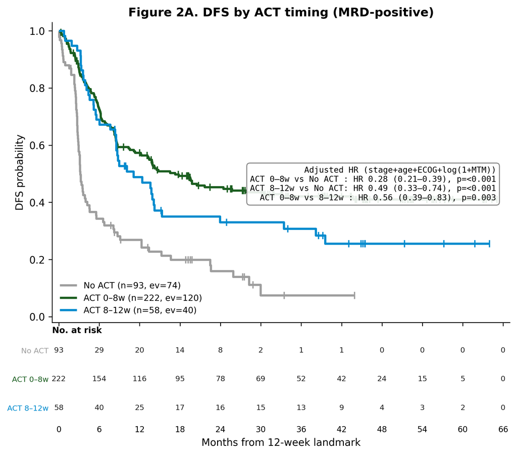

Figure 2B — OS by ACT timing (12-week landmark Kaplan–Meier)

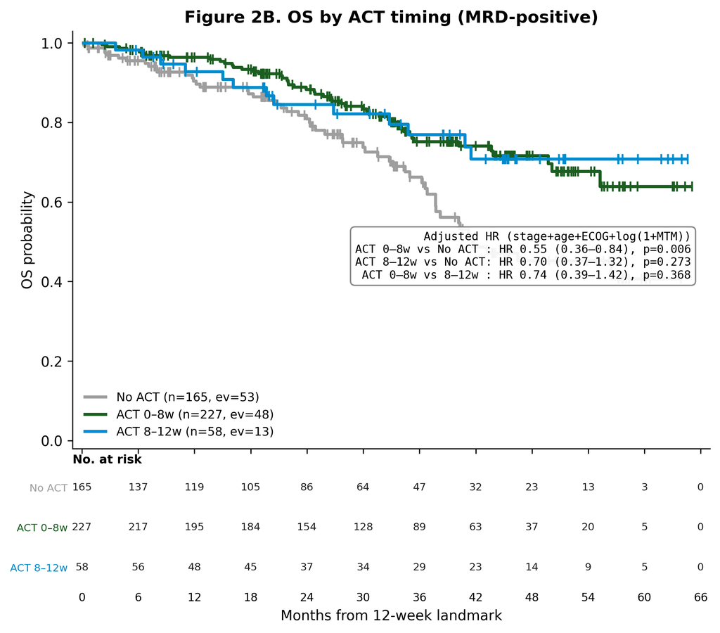

Adjusted landmark hazard ratios (Figures 2A / 2B)

| panel | endpoint | reference | comparison | HR | CI_low | CI_high | p |
| --- | --- | --- | --- | --- | --- | --- | --- |
| 2A | DFS | No ACT | ACT 0–8w | 0.284 | 0.207 | 0.390 | 0.00000 |
| 2A | DFS | No ACT | ACT 8–12w | 0.494 | 0.332 | 0.736 | 0.00053 |
| 2A | DFS | ACT 8–12w | ACT 0–8w | 0.565 | 0.386 | 0.826 | 0.00322 |
| 2B | OS | No ACT | ACT 0–8w | 0.554 | 0.363 | 0.845 | 0.00606 |
| 2B | OS | No ACT | ACT 8–12w | 0.700 | 0.370 | 1.324 | 0.27263 |
| 2B | OS | ACT 8–12w | ACT 0–8w | 0.743 | 0.389 | 1.418 | 0.36797 |

Supplementary Figure 1 — covariate-adjusted RMST gain in DFS

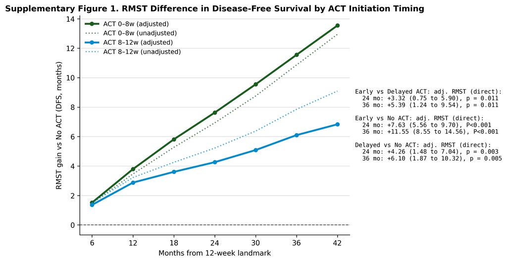

Supplementary Figure 1 — direct adjusted RMST contrasts (24 and 36 months)

| contrast | horizon_mo | RMST_diff_mo | CI_low | CI_high | p |
| --- | --- | --- | --- | --- | --- |
| Early vs Delayed | 24 | 3.32 | 0.75 | 5.90 | 0.0114 |
| Early vs Delayed | 36 | 5.39 | 1.24 | 9.54 | 0.0110 |
| Early vs No ACT | 24 | 7.63 | 5.56 | 9.70 | 0.0000 |
| Early vs No ACT | 36 | 11.55 | 8.55 | 14.56 | 0.0000 |
| Delayed vs No ACT | 24 | 4.26 | 1.48 | 7.04 | 0.0027 |
| Delayed vs No ACT | 36 | 6.10 | 1.87 | 10.32 | 0.0047 |

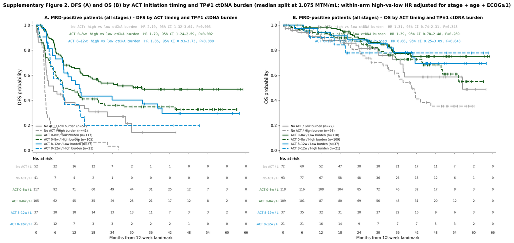

Supplementary Figure 2 — within-arm high vs low ctDNA-burden hazard ratios

| arm | endpoint | n_low | n_high | ev_low | ev_high | HR_high_vs_low | CI_low | CI_high | adj_p | logrank_p |
| --- | --- | --- | --- | --- | --- | --- | --- | --- | --- | --- |
| No ACT | DFS | 49 | 40 | 36 | 38 | 2.187 | 1.315 | 3.638 | 0.0026 | 0.0002 |
| ACT 0–8w | DFS | 116 | 104 | 54 | 64 | 1.787 | 1.236 | 2.585 | 0.0020 | 0.0022 |
| ACT 8–12w | DFS | 36 | 20 | 24 | 16 | 1.861 | 0.928 | 3.729 | 0.0801 | 0.0895 |
| No ACT | OS | 69 | 91 | 19 | 34 | 1.311 | 0.744 | 2.311 | 0.3482 | 0.1721 |
| ACT 0–8w | OS | 117 | 107 | 21 | 27 | 1.387 | 0.776 | 2.478 | 0.2695 | 0.1525 |
| ACT 8–12w | OS | 36 | 20 | 9 | 4 | 0.881 | 0.251 | 3.093 | 0.8427 | 0.9115 |

## Figure 2C–2E — prognostic analysis within late-starter ACT patients (ACT 8–24w)

### Code

```
import os
import numpy as np
import pandas as pd
from lifelines import CoxPHFitter

from _common import OUT_DIR, DAYS_PER_MONTH, load_act_timing_cohort, simplify_stage, \
    plot_forest, fmt_p

MIN_EVENTS = 5
STAGE_ORDER = ["I\u2013II", "III", "IV"]

m = load_act_timing_cohort()
m["stage_num"] = m["p_StagePath"].apply(simplify_stage)
m["age"] = pd.to_numeric(m["Age"], errors="coerce")
m["ecog_ge1"] = np.where(pd.to_numeric(m["ECOG"], errors="coerce") >= 1, 1.0, 0.0)
m.loc[m["ECOG"].isna(), "ecog_ge1"] = np.nan
m["male"] = np.where(m["Sex"] == "Male", 1.0, np.where(m["Sex"] == "Female", 0.0, np.nan))
m["pT4"] = m["pT"].apply(lambda x: 1.0 if str(x).startswith("pT4")
                         else (0.0 if str(x).startswith(("pT1", "pT2", "pT3")) else np.nan))
m["pN_pos"] = m["pN"].apply(lambda x: 0.0 if str(x).startswith("pN0")
                            else (1.0 if str(x).startswith(("pN1", "pN2")) else np.nan))
m["right_sided"] = np.where(m["LocationGrpA"] == "Right-sided colon", 1.0,
                            np.where(m["LocationGrpA"] == "Left-sided colon", 0.0, np.nan))
m["rectum"] = np.where(m["LocationGrpB"] == "Rectum", 1.0,
                       np.where(m["LocationGrpB"] == "Colon", 0.0, np.nan))

m["msi_h"]    = m["msi_call"].map({"MSS": 0.0, "MSI-High": 1.0})
m["ras_pos"]  = m["ras_call"].map({"WT": 0.0, "MUT": 1.0})
m["braf_pos"] = m["braf_call"].map({"WT": 0.0, "MUT": 1.0})
m["lvi_present"] = m["p_LVI"].apply(lambda x: np.nan if pd.isna(x)
                                    else (1.0 if ("Ly1" in str(x) or "V1" in str(x)) else 0.0))
m["pni_present"] = m["p_PNI"].apply(lambda x: 1.0 if str(x).startswith("Pn1")
                                    else (0.0 if str(x).startswith("Pn0") else np.nan))
m["mrd_pos_f"] = m["mrd_pos"].astype(float)
m["age10"] = m["age"] / 10.0
m["log1p_mtm"] = np.log1p(pd.to_numeric(m["mrd_mtm"], errors="coerce"))

LM_DAYS = 84
coh = m[m["arm"].isin(["delayed", "late"])].copy()
_dfs = pd.to_numeric(coh["dfs_days"], errors="coerce")
_evt = pd.to_numeric(coh["dfs_evt"], errors="coerce")
coh = coh[_dfs.notna() & _evt.notna() & (_dfs >= LM_DAYS)].copy()
coh["_t"] = (pd.to_numeric(coh["dfs_days"], errors="coerce") - LM_DAYS) / DAYS_PER_MONTH
coh["_e"] = pd.to_numeric(coh["dfs_evt"], errors="coerce")
_same = (coh["_t"] == 0) & (coh["_e"] == 1)
coh.loc[_same, "_t"] = 1.0 / DAYS_PER_MONTH
print(f"Late-starter cohort (ACT 8\u201324w), 12-week landmark: n={len(coh)}, DFS events={int(coh['_e'].sum())}")

def stage_group(d):
    g = pd.to_numeric(d["stage_num"], errors="coerce")
    return pd.Series(np.select([g.isin([1, 2]), g.eq(3), g.eq(4)], STAGE_ORDER, default=None),
                     index=d.index).where(lambda s: s.notna())

def build_stage_cols(d):
    grp = stage_group(d)
    if grp.dropna().nunique() < 2:
        return []
    ref = [s for s in STAGE_ORDER if (grp == s).any()][0]
    dd = pd.get_dummies(grp, prefix="stage").astype(float)
    dd = dd.drop(columns=[f"stage_{ref}"]) if f"stage_{ref}" in dd.columns else dd
    order = [f"stage_{s}" for s in STAGE_ORDER if f"stage_{s}" in dd.columns]
    dd = dd[order]
    for c in dd.columns:
        d[c] = dd[c]
    return list(dd.columns)

def stage_ref(d):
    present = [s for s in STAGE_ORDER if (stage_group(d) == s).any()]
    return present[0] if len(present) >= 2 else "reference"

def cox_fit(d, cols, penalizers=(0.0, 0.1, 0.5, 1.0)):
    use = d.dropna(subset=["_t", "_e"] + cols).copy()
    n, ev = len(use), int(use["_e"].sum())
    meta = {"n": n, "events": ev, "cindex": np.nan, "penalized": None}
    if n == 0 or ev < MIN_EVENTS or use[cols].nunique().min() < 2:
        return [], meta
    fit_df = use[["_t", "_e"] + cols].reset_index(drop=True)
    last = None
    for pen in penalizers:
        try:
            cph = CoxPHFitter(penalizer=pen).fit(fit_df, duration_col="_t", event_col="_e")
            rows = [{"covariate": c, "HR": float(np.exp(cph.params_[c])),
                     "CI_low": float(np.exp(cph.confidence_intervals_.loc[c, "95% lower-bound"])),
                     "CI_high": float(np.exp(cph.confidence_intervals_.loc[c, "95% upper-bound"])),
                     "p": float(cph.summary.loc[c, "p"])} for c in cols if c in cph.params_.index]
            meta.update({"cindex": float(cph.concordance_index_), "penalized": bool(pen > 0)})
            degenerate = any((abs(np.log(r["HR"])) > 5) or (not np.isfinite(r["CI_low"]))
                             or (not np.isfinite(r["CI_high"])) or r["CI_low"] <= 0 for r in rows)
            last = (rows, dict(meta))
            if not degenerate:
                return rows, meta
        except Exception:
            continue
    return last if last is not None else ([], meta)

UNI_VARS = [("MRD-window ctDNA positive", "mrd_pos_f"), ("Age (per 10 y)", "age10"),
            ("ECOG \u22651", "ecog_ge1"), ("Male sex", "male"), ("pT4 (vs T1\u2013T3)", "pT4"),
            ("Node positive (N1/N2)", "pN_pos"), ("Right-sided (vs left)", "right_sided"),
            ("Rectum (vs colon)", "rectum"), ("MSI-H (vs MSS/pMMR)", "msi_h"),
            ("RAS mutant", "ras_pos"), ("BRAF mutant", "braf_pos"),
            ("LVI present", "lvi_present"), ("PNI present", "pni_present"),
            ("log(1+MTM) [all]", "log1p_mtm")]

def label_of(col, ref_roman):
    if col.startswith("stage_"):
        return f"Stage {col.split('_', 1)[1]} (vs {ref_roman})"
    for lab, c in UNI_VARS:
        if c == col:
            return lab
    return col

stage_cols = build_stage_cols(coh)
ref = stage_ref(coh)
uni_rows, uni_forest = [], []
srows, smeta = cox_fit(coh, stage_cols)
for r in srows:
    uni_rows.append({"variable": label_of(r["covariate"], ref), "HR": round(r["HR"], 3),
                     "CI_low": round(r["CI_low"], 3), "CI_high": round(r["CI_high"], 3),
                     "p": round(r["p"], 4), "n": smeta["n"], "events": smeta["events"]})
    uni_forest.append((label_of(r["covariate"], ref), r["HR"], r["CI_low"], r["CI_high"], r["p"]))
for lab, col in UNI_VARS:
    rows, meta = cox_fit(coh, [col])
    if not rows:
        continue
    r = rows[0]
    uni_rows.append({"variable": lab, "HR": round(r["HR"], 3), "CI_low": round(r["CI_low"], 3),
                     "CI_high": round(r["CI_high"], 3), "p": round(r["p"], 4),
                     "n": meta["n"], "events": meta["events"]})
    uni_forest.append((lab, r["HR"], r["CI_low"], r["CI_high"], r["p"]))

uni_df = pd.DataFrame(uni_rows)
uni_df.to_csv(os.path.join(OUT_DIR, "figure_2C_univariable_DFS.csv"), index=False)
plot_forest(uni_forest, "Figure 2C. Univariable predictors of DFS (ACT 8\u201324w)",
            "figure_2C_univariable_forest", xlabel="Hazard ratio for DFS event (95% CI, log scale)",
            subtitle=f"n={len(coh)}, events={int(coh['_e'].sum())}; each row = separate model")
print("\nFIGURE 2C — univariable predictors of DFS")
print(uni_df.to_string(index=False))

core_cols = ["mrd_pos_f"] + stage_cols + ["age10", "ecog_ge1", "right_sided"]
crows, cmeta = cox_fit(coh, core_cols)
core_rows, core_forest = [], []
for r in crows:
    core_rows.append({"variable": label_of(r["covariate"], ref), "HR": round(r["HR"], 3),
                      "CI_low": round(r["CI_low"], 3), "CI_high": round(r["CI_high"], 3),
                      "p": round(r["p"], 4), "n_model": cmeta["n"], "events_model": cmeta["events"],
                      "C_index": round(cmeta["cindex"], 3)})
    core_forest.append((label_of(r["covariate"], ref), r["HR"], r["CI_low"], r["CI_high"], r["p"]))
core_df = pd.DataFrame(core_rows)
core_df.to_csv(os.path.join(OUT_DIR, "figure_2D_multivariable_CORE_DFS.csv"), index=False)
plot_forest(core_forest, "Figure 2D. Multivariable (CORE) predictors of DFS (ACT 8\u201324w)",
            "figure_2D_multivariable_forest", xlabel="Hazard ratio for DFS event (95% CI, log scale)",
            subtitle=f"n={cmeta['n']}, events={cmeta['events']}, C-index={cmeta['cindex']:.3f}; mutually adjusted")
print(f"\nFIGURE 2D — CORE multivariable model (n={cmeta['n']}, events={cmeta['events']}, "
      f"C-index={cmeta['cindex']:.3f})")
print(core_df.to_string(index=False))

pos = coh[coh["mrd_pos"] & (coh["stage_num"].isin([1, 2, 3]))].copy()
pos["stage_III"] = (pd.to_numeric(pos["stage_num"], errors="coerce") == 3).astype(float)
e2_cols = ["log1p_mtm", "stage_III", "age10", "ecog_ge1", "right_sided"]
erows, emeta = cox_fit(pos, e2_cols, penalizers=(0.0,))
LBL2E = {"log1p_mtm": "log(1+MTM) per unit", "stage_III": "Stage III (vs I\u2013II)",
         "age10": "Age (per 10 y)", "ecog_ge1": "ECOG \u22651", "right_sided": "Right-sided (vs left)"}
e2_rows, e2_forest = [], []
for r in erows:
    e2_rows.append({"variable": LBL2E.get(r["covariate"], r["covariate"]), "HR": round(r["HR"], 3),
                    "CI_low": round(r["CI_low"], 3), "CI_high": round(r["CI_high"], 3),
                    "p": round(r["p"], 4), "n_model": emeta["n"], "events_model": emeta["events"],
                    "C_index": round(emeta["cindex"], 3)})
    e2_forest.append((LBL2E.get(r["covariate"], r["covariate"]), r["HR"], r["CI_low"], r["CI_high"], r["p"]))
e2_df = pd.DataFrame(e2_rows)
e2_df.to_csv(os.path.join(OUT_DIR, "figure_2E_MRDpos_ctdna_burden_DFS.csv"), index=False)
plot_forest(e2_forest, "Figure 2E. Multivariate analysis with ctDNA levels log(1+MTM/mL) (ACT 8\u201324w) (Stage I\u2013III)",
            "figure_2E_ctdna_burden_forest", xlabel="Hazard ratio for DFS event (95% CI, log scale)",
            subtitle=f"MRD+ (Stage I\u2013III); n={emeta['n']}, events={emeta['events']}, C-index={emeta['cindex']:.3f}")
print(f"\nFIGURE 2E — ctDNA burden (MRD+, Stage I\u2013III; n={emeta['n']}, events={emeta['events']})")
print(e2_df.to_string(index=False))
```

### Console output

```
Late-starter cohort (ACT 8–24w), 12-week landmark: n=292, DFS events=81

FIGURE 2C — univariable predictors of DFS
                 variable    HR  CI_low  CI_high      p   n  events
      Stage III (vs I–II) 1.610   0.936    2.770 0.0855 292      81
       Stage IV (vs I–II) 3.371   1.453    7.820 0.0047 292      81
MRD-window ctDNA positive 7.670   4.924   11.947 0.0000 292      81
           Age (per 10 y) 1.274   1.019    1.593 0.0339 292      81
                  ECOG ≥1 1.287   0.620    2.672 0.4980 292      81
                 Male sex 0.876   0.566    1.354 0.5510 292      81
           pT4 (vs T1–T3) 1.466   0.922    2.330 0.1060 288      80
    Node positive (N1/N2) 1.650   0.965    2.822 0.0673 286      79
    Right-sided (vs left) 1.161   0.740    1.820 0.5165 291      80
        Rectum (vs colon) 0.895   0.484    1.655 0.7241 291      80
      MSI-H (vs MSS/pMMR) 0.111   0.015    0.798 0.0290 288      80
               RAS mutant 0.891   0.568    1.398 0.6163 288      80
              BRAF mutant 0.750   0.274    2.050 0.5745 288      80
              LVI present 1.190   0.571    2.481 0.6426 279      73
              PNI present 1.351   0.837    2.180 0.2186 269      68
         log(1+MTM) [all] 2.326   1.891    2.861 0.0000 292      81

FIGURE 2D — CORE multivariable model (n=291, events=80, C-index=0.768)
                 variable    HR  CI_low  CI_high      p  n_model  events_model  C_index
MRD-window ctDNA positive 9.816   6.093   15.815 0.0000      291            80    0.768
      Stage III (vs I–II) 2.075   1.191    3.618 0.0100      291            80    0.768
       Stage IV (vs I–II) 7.496   2.952   19.034 0.0000      291            80    0.768
           Age (per 10 y) 1.151   0.908    1.458 0.2442      291            80    0.768
                  ECOG ≥1 1.293   0.607    2.757 0.5053      291            80    0.768
    Right-sided (vs left) 1.788   1.115    2.867 0.0158      291            80    0.768

FIGURE 2E — ctDNA burden (MRD+, Stage I–III; n=56, events=40)
             variable    HR  CI_low  CI_high      p  n_model  events_model  C_index
  log(1+MTM) per unit 1.724   1.271    2.339 0.0005       56            40    0.646
  Stage III (vs I–II) 1.153   0.538    2.470 0.7146       56            40    0.646
       Age (per 10 y) 1.280   0.838    1.955 0.2539       56            40    0.646
              ECOG ≥1 1.518   0.483    4.765 0.4750       56            40    0.646
Right-sided (vs left) 1.605   0.774    3.329 0.2036       56            40    0.646
```

### Results

Figure 2C — univariable predictors of DFS

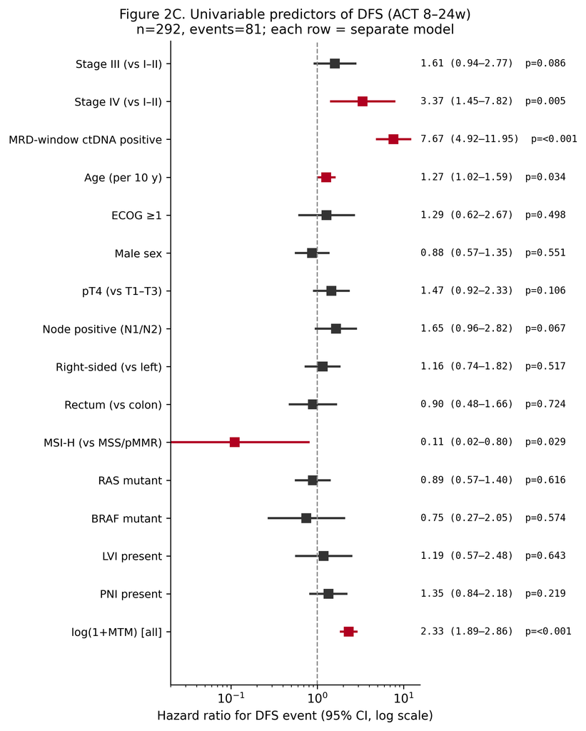

Figure 2C — univariable results table

| variable | HR | CI_low | CI_high | p | n | events |
| --- | --- | --- | --- | --- | --- | --- |
| Stage III (vs I–II) | 1.610 | 0.936 | 2.770 | 0.0855 | 292 | 81 |
| Stage IV (vs I–II) | 3.371 | 1.453 | 7.820 | 0.0047 | 292 | 81 |
| MRD-window ctDNA positive | 7.670 | 4.924 | 11.947 | 0.0000 | 292 | 81 |
| Age (per 10 y) | 1.274 | 1.019 | 1.593 | 0.0339 | 292 | 81 |
| ECOG ≥1 | 1.287 | 0.620 | 2.672 | 0.4980 | 292 | 81 |
| Male sex | 0.876 | 0.566 | 1.354 | 0.5510 | 292 | 81 |
| pT4 (vs T1–T3) | 1.466 | 0.922 | 2.330 | 0.1060 | 288 | 80 |
| Node positive (N1/N2) | 1.650 | 0.965 | 2.822 | 0.0673 | 286 | 79 |
| Right-sided (vs left) | 1.161 | 0.740 | 1.820 | 0.5165 | 291 | 80 |
| Rectum (vs colon) | 0.895 | 0.484 | 1.655 | 0.7241 | 291 | 80 |
| MSI-H (vs MSS/pMMR) | 0.111 | 0.015 | 0.798 | 0.0290 | 288 | 80 |
| RAS mutant | 0.891 | 0.568 | 1.398 | 0.6163 | 288 | 80 |
| BRAF mutant | 0.750 | 0.274 | 2.050 | 0.5745 | 288 | 80 |
| LVI present | 1.190 | 0.571 | 2.481 | 0.6426 | 279 | 73 |
| PNI present | 1.351 | 0.837 | 2.180 | 0.2186 | 269 | 68 |
| log(1+MTM) [all] | 2.326 | 1.891 | 2.861 | 0.0000 | 292 | 81 |

Figure 2D — multivariable (CORE) predictors of DFS

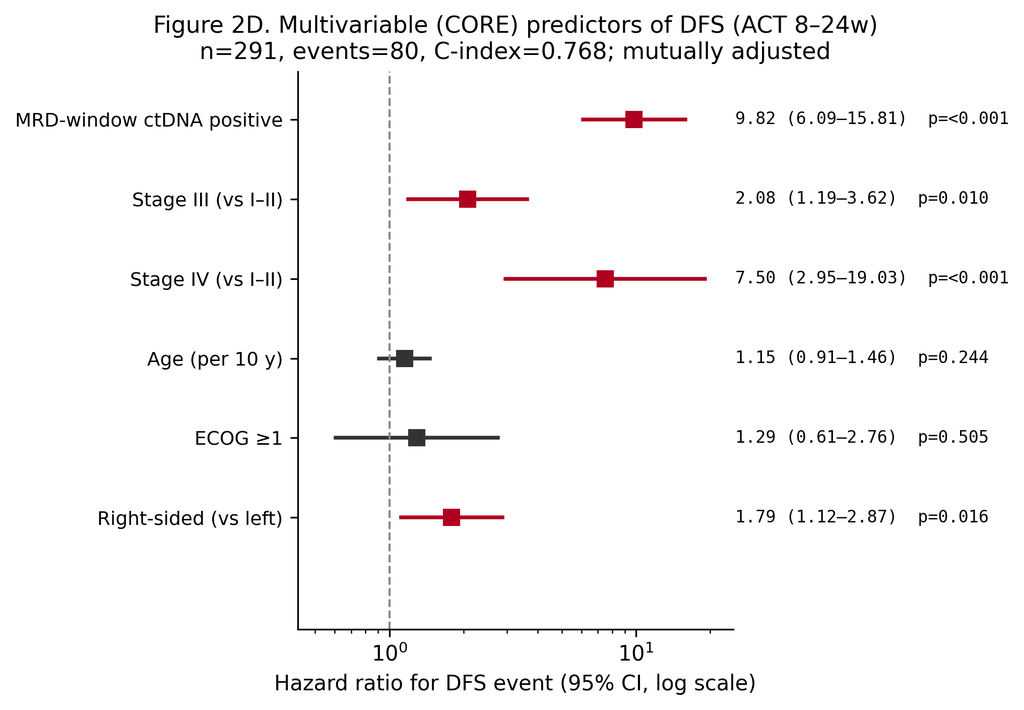

Figure 2D — CORE model results table

| variable | HR | CI_low | CI_high | p | n_model | events_model | C_index |
| --- | --- | --- | --- | --- | --- | --- | --- |
| MRD-window ctDNA positive | 9.816 | 6.093 | 15.815 | 0.0000 | 291 | 80 | 0.768 |
| Stage III (vs I–II) | 2.075 | 1.191 | 3.618 | 0.0100 | 291 | 80 | 0.768 |
| Stage IV (vs I–II) | 7.496 | 2.952 | 19.034 | 0.0000 | 291 | 80 | 0.768 |
| Age (per 10 y) | 1.151 | 0.908 | 1.458 | 0.2442 | 291 | 80 | 0.768 |
| ECOG ≥1 | 1.293 | 0.607 | 2.757 | 0.5053 | 291 | 80 | 0.768 |
| Right-sided (vs left) | 1.788 | 1.115 | 2.867 | 0.0158 | 291 | 80 | 0.768 |

Figure 2E — Multivariate analysis with ctDNA levels log(1+MTM/mL) (ACT 8–24w) (Stage I–III)

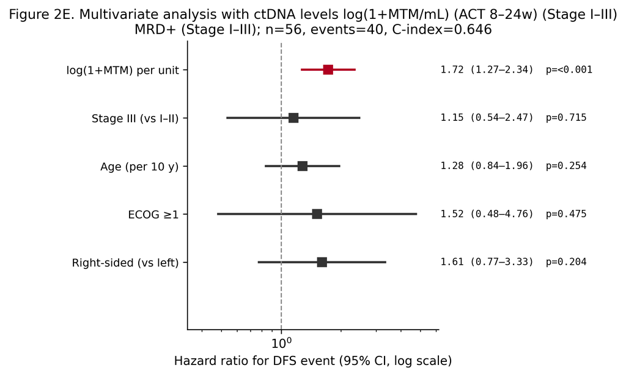

Figure 2E — results table

| variable | HR | CI_low | CI_high | p | n_model | events_model | C_index |
| --- | --- | --- | --- | --- | --- | --- | --- |
| log(1+MTM) per unit | 1.724 | 1.271 | 2.339 | 0.0005 | 56 | 40 | 0.646 |
| Stage III (vs I–II) | 1.153 | 0.538 | 2.470 | 0.7146 | 56 | 40 | 0.646 |
| Age (per 10 y) | 1.280 | 0.838 | 1.955 | 0.2539 | 56 | 40 | 0.646 |
| ECOG ≥1 | 1.518 | 0.483 | 4.765 | 0.4750 | 56 | 40 | 0.646 |
| Right-sided (vs left) | 1.605 | 0.774 | 3.329 | 0.2036 | 56 | 40 | 0.646 |

## Post-operative complication confounding assessment (Cohort 1)

### Code

```
import os
import numpy as np
import pandas as pd
from lifelines import CoxPHFitter
from scipy.stats import fisher_exact

from _common import OUT_DIR, DAYS_PER_MONTH, load_act_timing_cohort, \
    simplify_stage, stage_dummies, fmt_p

LM = 84
MODEL_COVS = ["stage_num", "age", "ecog_ge1", "log_mtm"]

m = load_act_timing_cohort()
m["stage_num"] = m["p_StagePath"].apply(simplify_stage)
pos = m[m["mrd_pos"]].copy()

ed = pos[pos["arm"].isin(["early", "delayed"])].copy()
ed["age"] = pd.to_numeric(ed["Age"], errors="coerce")
ed["ecog_ge1"] = np.where(pd.to_numeric(ed["ECOG"], errors="coerce") >= 1, 1.0, 0.0)
ed.loc[ed["ECOG"].isna(), "ecog_ge1"] = np.nan
ed["log_mtm"] = np.log1p(pd.to_numeric(ed["mrd_mtm"], errors="coerce"))
ed["cd2"] = pd.to_numeric(ed["cd2"], errors="coerce")

ed = ed[ed["dfs_days"].notna() & (ed["dfs_days"] >= LM)].copy()
ed["_t"] = (pd.to_numeric(ed["dfs_days"], errors="coerce") - LM) / DAYS_PER_MONTH
ed["_e"] = pd.to_numeric(ed["dfs_evt"], errors="coerce").astype(int)
same = (ed["_t"] == 0) & (ed["_e"] == 1)
ed.loc[same, "_t"] = 1.0 / DAYS_PER_MONTH

base_full = ed.dropna(subset=["_t", "_e"] + MODEL_COVS).copy()
cc = base_full.dropna(subset=["cd2"]).copy()


def fit_delayed_hr(dd, extra_cols=()):
    parts = [stage_dummies(dd["stage_num"], "stage"), dd[["age"]].astype(float),
             dd[["ecog_ge1"]].astype(float), dd[["log_mtm"]].astype(float)]
    for c in extra_cols:
        parts.append(dd[[c]].astype(float))
    adj = pd.concat(parts, axis=1)
    arm = pd.get_dummies(dd["arm"], prefix="g").astype(float)
    if "g_early" in arm.columns:
        arm = arm.drop(columns=["g_early"])
    fit_df = pd.concat([dd[["_t", "_e"]].reset_index(drop=True), arm.reset_index(drop=True),
                        adj.reset_index(drop=True)], axis=1)
    for pen in (0.0, 0.1, 0.5):
        try:
            cph = CoxPHFitter(penalizer=pen).fit(fit_df, "_t", "_e")
            col = "g_delayed"
            return (float(np.exp(cph.params_[col])),
                    float(np.exp(cph.confidence_intervals_.loc[col, "95% lower-bound"])),
                    float(np.exp(cph.confidence_intervals_.loc[col, "95% upper-bound"])),
                    float(cph.summary.loc[col, "p"]), pen > 0, len(dd), int(dd["_e"].sum()))
        except Exception:
            continue
    return (np.nan,) * 7


def fit_cov_hr(dd, col):
    parts = [stage_dummies(dd["stage_num"], "stage"), dd[["age"]].astype(float),
             dd[["ecog_ge1"]].astype(float), dd[["log_mtm"]].astype(float), dd[[col]].astype(float)]
    arm = pd.get_dummies(dd["arm"], prefix="g").astype(float)
    if "g_early" in arm.columns:
        arm = arm.drop(columns=["g_early"])
    parts.append(arm)
    fit_df = pd.concat([dd[["_t", "_e"]].reset_index(drop=True),
                        pd.concat(parts, axis=1).reset_index(drop=True)], axis=1)
    for pen in (0.0, 0.1, 0.5):
        try:
            cph = CoxPHFitter(penalizer=pen).fit(fit_df, "_t", "_e")
            return (float(np.exp(cph.params_[col])),
                    float(np.exp(cph.confidence_intervals_.loc[col, "95% lower-bound"])),
                    float(np.exp(cph.confidence_intervals_.loc[col, "95% upper-bound"])),
                    float(cph.summary.loc[col, "p"]), pen > 0)
        except Exception:
            continue
    return (np.nan,) * 5


print("=" * 78)
print("Surgical-complication (Clavien-Dindo >=2) confounding analysis")
print("=" * 78)
print(f"Early+delayed after 12-wk landmark & complete model covariates : n={len(base_full)} "
      f"(early={int((base_full['arm']=='early').sum())}, delayed={int((base_full['arm']=='delayed').sum())})")
print(f"Complication status known (CD>=2 non-missing)                  : n={len(cc)} "
      f"(missing = {len(base_full) - len(cc)})")

tab = pd.crosstab(cc["arm"], cc["cd2"])
print("\n(a) Association of complication with ACT timing (exposure):")
rate = {}
for a in ["early", "delayed"]:
    n1 = int(tab.loc[a].get(1.0, 0)); n0 = int(tab.loc[a].get(0.0, 0))
    rate[a] = 100 * n1 / (n0 + n1)
    print(f"    {a:<8}: CD>=2 {n1}/{n0 + n1} ({rate[a]:.1f}%)")
orr, pf = fisher_exact([[int(tab.loc["early", 1.0]), int(tab.loc["early", 0.0])],
                        [int(tab.loc["delayed", 1.0]), int(tab.loc["delayed", 0.0])]])
print(f"    Fisher exact (delayed vs early CD>=2): OR={orr:.3f}, p={pf:.3f}")

cd_hr = fit_cov_hr(cc, "cd2")
print("\n(b) Association of complication with DFS (adjusted for arm+stage+age+ECOG+log(1+MTM)):")
print(f"    CD>=2 vs none : HR={cd_hr[0]:.3f} ({cd_hr[1]:.3f}-{cd_hr[2]:.3f}) p={cd_hr[3]:.3f}")

hr_primary = fit_delayed_hr(base_full)
hr_base_cc = fit_delayed_hr(cc)
hr_adj_cc  = fit_delayed_hr(cc, extra_cols=["cd2"])
pct = 100 * (hr_adj_cc[0] - hr_base_cc[0]) / hr_base_cc[0]


def inv(tup):
    return 1 / tup[0], 1 / tup[2], 1 / tup[1], tup[3]


print("\n(c) Delayed (8-12w) vs Early (0-8w) DFS HR — change-in-estimate:")
print(f"    Primary model (full n={hr_primary[5]}, ev={hr_primary[6]})          : "
      f"HR={hr_primary[0]:.3f} ({hr_primary[1]:.3f}-{hr_primary[2]:.3f}) p={hr_primary[3]:.4f}")
print(f"    Base model, complication-known subset (n={hr_base_cc[5]}, ev={hr_base_cc[6]}) : "
      f"HR={hr_base_cc[0]:.3f} ({hr_base_cc[1]:.3f}-{hr_base_cc[2]:.3f}) p={hr_base_cc[3]:.4f}")
print(f"    + adjusted for CD>=2 complication (same subset)          : "
      f"HR={hr_adj_cc[0]:.3f} ({hr_adj_cc[1]:.3f}-{hr_adj_cc[2]:.3f}) p={hr_adj_cc[3]:.4f}")
print(f"    Change in timing HR from adding complication             : {pct:+.1f}%")
e = inv(hr_base_cc)
print(f"\n    Manuscript direction — Early (0-8w) vs Delayed (8-12w), adjusted, N={hr_base_cc[5]}: "
      f"HR={e[0]:.2f} ({e[1]:.2f}-{e[2]:.2f}) p={fmt_p(e[3]) or '<0.001'}")

res = pd.DataFrame([
    {"step": "(a) complication ~ timing", "metric": "CD>=2 rate early (%)", "estimate": round(rate["early"], 1)},
    {"step": "(a) complication ~ timing", "metric": "CD>=2 rate delayed (%)", "estimate": round(rate["delayed"], 1)},
    {"step": "(a) complication ~ timing", "metric": "CD>=2 delayed vs early OR", "estimate": round(orr, 3), "p": round(pf, 4)},
    {"step": "(b) complication ~ DFS", "metric": "HR CD>=2 (adj)", "estimate": round(cd_hr[0], 3),
     "ci_low": round(cd_hr[1], 3), "ci_high": round(cd_hr[2], 3), "p": round(cd_hr[3], 4)},
    {"step": "(c) timing HR base (cc subset)", "metric": "HR delayed vs early", "estimate": round(hr_base_cc[0], 3),
     "ci_low": round(hr_base_cc[1], 3), "ci_high": round(hr_base_cc[2], 3), "p": round(hr_base_cc[3], 4)},
    {"step": "(c) timing HR + complication", "metric": "HR delayed vs early (adj CD>=2)", "estimate": round(hr_adj_cc[0], 3),
     "ci_low": round(hr_adj_cc[1], 3), "ci_high": round(hr_adj_cc[2], 3), "p": round(hr_adj_cc[3], 4)},
    {"step": "(c) change-in-estimate", "metric": "percent change in timing HR", "estimate": round(pct, 1)},
    {"step": "(summary) manuscript direction", "metric": "Early vs Delayed adj HR", "estimate": round(e[0], 3),
     "ci_low": round(e[1], 3), "ci_high": round(e[2], 3), "p": round(e[3], 4)},
])
out = os.path.join(OUT_DIR, "complication_confounding_summary.csv")
res.to_csv(out, index=False)
print(f"\nSaved -> {out}")
```

### Console output

```
==============================================================================
Surgical-complication (Clavien-Dindo >=2) confounding analysis
==============================================================================
Early+delayed after 12-wk landmark & complete model covariates : n=276 (early=220, delayed=56)
Complication status known (CD>=2 non-missing)                  : n=214 (missing = 62)

(a) Association of complication with ACT timing (exposure):
    early   : CD>=2 23/170 (13.5%)
    delayed : CD>=2 6/44 (13.6%)
    Fisher exact (delayed vs early CD>=2): OR=0.991, p=1.000

(b) Association of complication with DFS (adjusted for arm+stage+age+ECOG+log(1+MTM)):
    CD>=2 vs none : HR=1.279 (0.796-2.055) p=0.310

(c) Delayed (8-12w) vs Early (0-8w) DFS HR — change-in-estimate:
    Primary model (full n=276, ev=158)          : HR=1.771 (1.211-2.590) p=0.0032
    Base model, complication-known subset (n=214, ev=131) : HR=1.778 (1.165-2.712) p=0.0076
    + adjusted for CD>=2 complication (same subset)          : HR=1.785 (1.170-2.724) p=0.0072
    Change in timing HR from adding complication             : +0.4%

    Manuscript direction — Early (0-8w) vs Delayed (8-12w), adjusted, N=214: HR=0.56 (0.37-0.86) p=0.008

Saved -> manuscript_project/manuscript_final_code/outputs/complication_confounding_summary.csv
```

### Results

Confounding assessment summary (exposure association, outcome association, change-in-estimate)

| step | metric | estimate | p | ci_low | ci_high |
| --- | --- | --- | --- | --- | --- |
| (a) complication ~ timing | CD>=2 rate early (%) | 13.500 |  |  |  |
| (a) complication ~ timing | CD>=2 rate delayed (%) | 13.600 |  |  |  |
| (a) complication ~ timing | CD>=2 delayed vs early OR | 0.991 | 1.0 |  |  |
| (b) complication ~ DFS | HR CD>=2 (adj) | 1.279 | 0.31 | 0.796 | 2.055 |
| (c) timing HR base (cc subset) | HR delayed vs early | 1.778 | 0.0076 | 1.165 | 2.712 |
| (c) timing HR + complication | HR delayed vs early (adj CD>=2) | 1.785 | 0.0072 | 1.17 | 2.724 |
| (c) change-in-estimate | percent change in timing HR | 0.400 |  |  |  |
| (summary) manuscript direction | Early vs Delayed adj HR | 0.563 | 0.0076 | 0.369 | 0.858 |

## Supplementary Table 4 — Cohort 3 baseline characteristics (ACT-duration cohort, N = 1,010)

### Code

```
import os
import numpy as np
import pandas as pd

from _common import OUT_DIR, load_dynamics_cohort, derive_baseline, build_demographics_table

d = load_dynamics_cohort()
d["mrd_pos"] = pd.to_numeric(d["MTM_tp1"], errors="coerce") > 0
m = derive_baseline(d, "MTM_tp1")

cols = [
    ("All",       m),
    ("Long ACT",  m[m["cohort_def"] == "long"]),
    ("Short ACT", m[m["cohort_def"] == "short"]),
]
groups = [m[m["cohort_def"] == "long"], m[m["cohort_def"] == "short"]]
supp4 = build_demographics_table(cols, groups, include_mrd_row=True)

out = os.path.join(OUT_DIR, "supplementary_table_4_cohort3_1010_longVsShort.csv")
supp4.to_csv(out, index=False)

pd.set_option("display.max_rows", None, "display.width", 220)
print("=" * 110)
print("SUPPLEMENTARY TABLE 4 — ctDNA-dynamics / ACT-duration cohort (N = 1,010): Long vs Short ACT")
print("=" * 110)
print(supp4.to_string(index=False))
print(f"\nSaved -> {out}")
```

### Console output

```
==============================================================================================================
SUPPLEMENTARY TABLE 4 — ctDNA-dynamics / ACT-duration cohort (N = 1,010): Long vs Short ACT
==============================================================================================================
                         Characteristic              All         Long ACT        Short ACT      p
                                      N            1,010              662              348
 Follow-up time in months, median [IQR] 42.3 [33.0–53.5] 42.8 [34.4–53.8] 41.4 [30.0–52.0]      –
                MRD-window ctDNA status                                                     0.017
                               Negative      805 (79.7%)      513 (77.5%)      292 (83.9%)
                               Positive      205 (20.3%)      149 (22.5%)       56 (16.1%)
                   Age, median [IQR], y       66 [56–72]       66 [55–72]       66 [56–73]  0.557
                              Age group                                                     0.712
                                    <65      463 (45.8%)      308 (46.5%)      155 (44.5%)
                                  65–74      399 (39.5%)      261 (39.4%)      138 (39.7%)
                                    ≥75      148 (14.7%)       93 (14.0%)       55 (15.8%)
                                    Sex                                                     0.505
                                 Female      441 (43.7%)      284 (42.9%)      157 (45.1%)
                                   Male      569 (56.3%)      378 (57.1%)      191 (54.9%)
                ECOG performance status                                                     0.357
                                      0      942 (93.3%)      621 (93.8%)      321 (92.2%)
                                     ≥1        68 (6.7%)        41 (6.2%)        27 (7.8%)
                                Missing         0 (0.0%)         0 (0.0%)         0 (0.0%)
                       Pathologic stage                                                    <0.001
                                      I         2 (0.2%)         2 (0.3%)         0 (0.0%)
                                     II      182 (18.0%)       94 (14.2%)       88 (25.3%)
                                    III      768 (76.0%)      517 (78.1%)      251 (72.1%)
                                     IV        49 (4.9%)        42 (6.3%)         7 (2.0%)
                                Missing         9 (0.9%)         7 (1.1%)         2 (0.6%)
                     Primary tumor (pT)                                                     0.027
                                     T1        26 (2.6%)        17 (2.6%)         9 (2.6%)
                                     T2        49 (4.9%)        30 (4.5%)        19 (5.5%)
                                     T3      599 (59.3%)      373 (56.3%)      226 (64.9%)
                                     T4      328 (32.5%)      236 (35.6%)       92 (26.4%)
                                Missing         8 (0.8%)         6 (0.9%)         2 (0.6%)
                      Nodal status (pN)                                                    <0.001
                                     N0      188 (18.6%)      100 (15.1%)       88 (25.3%)
                                     N1      489 (48.4%)      295 (44.6%)      194 (55.7%)
                                     N2      322 (31.9%)      258 (39.0%)       64 (18.4%)
                                Missing        11 (1.1%)         9 (1.4%)         2 (0.6%)
                        Tumor sidedness                                                     0.615
                       Left-sided colon      696 (68.9%)      459 (69.3%)      237 (68.1%)
                      Right-sided colon      308 (30.5%)      198 (29.9%)      110 (31.6%)
                                Missing         6 (0.6%)         5 (0.8%)         1 (0.3%)
                           Primary site                                                     0.196
                                  Colon      822 (81.4%)      530 (80.1%)      292 (83.9%)
                                 Rectum      182 (18.0%)      127 (19.2%)       55 (15.8%)
                                Missing         6 (0.6%)         5 (0.8%)         1 (0.3%)
                         MMR/MSI status                                                     0.030
                                    MSS      927 (91.8%)      617 (93.2%)      310 (89.1%)
                                  MSI-H        83 (8.2%)        45 (6.8%)       38 (10.9%)
                                Missing         0 (0.0%)         0 (0.0%)         0 (0.0%)
                                    RAS                                                     0.181
                               Negative      583 (57.7%)      372 (56.2%)      211 (60.6%)
                               Positive      427 (42.3%)      290 (43.8%)      137 (39.4%)
                                Missing         0 (0.0%)         0 (0.0%)         0 (0.0%)
                                   BRAF                                                     0.011
                               Negative      926 (91.7%)      618 (93.4%)      308 (88.5%)
                               Positive        84 (8.3%)        44 (6.6%)       40 (11.5%)
                                Missing         0 (0.0%)         0 (0.0%)         0 (0.0%)
                Lymphovascular invasion                                                     0.004
                                 Absent      102 (10.1%)        53 (8.0%)       49 (14.1%)
                                Present      877 (86.8%)      584 (88.2%)      293 (84.2%)
                                Missing        31 (3.1%)        25 (3.8%)         6 (1.7%)
                    Perineural invasion                                                     0.343
                                 Absent      451 (44.7%)      286 (43.2%)      165 (47.4%)
                                Present      510 (50.5%)      339 (51.2%)      171 (49.1%)
                                Missing        49 (4.9%)        37 (5.6%)        12 (3.4%)
MRD-window MTM among MRD+, median [IQR] 0.85 [0.20–4.01] 0.73 [0.20–3.70] 1.13 [0.26–4.20]  0.465

Saved -> manuscript_project/manuscript_final_code/outputs/supplementary_table_4_cohort3_1010_longVsShort.csv
```

### Results

Supplementary Table 4 — ctDNA-dynamics / ACT-duration cohort: Long vs Short ACT

| Characteristic | All | Long ACT | Short ACT | p |
| --- | --- | --- | --- | --- |
| N | 1,010 | 662 | 348 |  |
| Follow-up time in months, median [IQR] | 42.3 [33.0–53.5] | 42.8 [34.4–53.8] | 41.4 [30.0–52.0] | – |
| MRD-window ctDNA status |  |  |  | 0.017 |
| Negative | 805 (79.7%) | 513 (77.5%) | 292 (83.9%) |  |
| Positive | 205 (20.3%) | 149 (22.5%) | 56 (16.1%) |  |
| Age, median [IQR], y | 66 [56–72] | 66 [55–72] | 66 [56–73] | 0.557 |
| Age group |  |  |  | 0.712 |
| <65 | 463 (45.8%) | 308 (46.5%) | 155 (44.5%) |  |
| 65–74 | 399 (39.5%) | 261 (39.4%) | 138 (39.7%) |  |
| ≥75 | 148 (14.7%) | 93 (14.0%) | 55 (15.8%) |  |
| Sex |  |  |  | 0.505 |
| Female | 441 (43.7%) | 284 (42.9%) | 157 (45.1%) |  |
| Male | 569 (56.3%) | 378 (57.1%) | 191 (54.9%) |  |
| ECOG performance status |  |  |  | 0.357 |
| 0 | 942 (93.3%) | 621 (93.8%) | 321 (92.2%) |  |
| ≥1 | 68 (6.7%) | 41 (6.2%) | 27 (7.8%) |  |
| Missing | 0 (0.0%) | 0 (0.0%) | 0 (0.0%) |  |
| Pathologic stage |  |  |  | <0.001 |
| I | 2 (0.2%) | 2 (0.3%) | 0 (0.0%) |  |
| II | 182 (18.0%) | 94 (14.2%) | 88 (25.3%) |  |
| III | 768 (76.0%) | 517 (78.1%) | 251 (72.1%) |  |
| IV | 49 (4.9%) | 42 (6.3%) | 7 (2.0%) |  |
| Missing | 9 (0.9%) | 7 (1.1%) | 2 (0.6%) |  |
| Primary tumor (pT) |  |  |  | 0.027 |
| T1 | 26 (2.6%) | 17 (2.6%) | 9 (2.6%) |  |
| T2 | 49 (4.9%) | 30 (4.5%) | 19 (5.5%) |  |
| T3 | 599 (59.3%) | 373 (56.3%) | 226 (64.9%) |  |
| T4 | 328 (32.5%) | 236 (35.6%) | 92 (26.4%) |  |
| Missing | 8 (0.8%) | 6 (0.9%) | 2 (0.6%) |  |
| Nodal status (pN) |  |  |  | <0.001 |
| N0 | 188 (18.6%) | 100 (15.1%) | 88 (25.3%) |  |
| N1 | 489 (48.4%) | 295 (44.6%) | 194 (55.7%) |  |
| N2 | 322 (31.9%) | 258 (39.0%) | 64 (18.4%) |  |
| Missing | 11 (1.1%) | 9 (1.4%) | 2 (0.6%) |  |
| Tumor sidedness |  |  |  | 0.615 |
| Left-sided colon | 696 (68.9%) | 459 (69.3%) | 237 (68.1%) |  |
| Right-sided colon | 308 (30.5%) | 198 (29.9%) | 110 (31.6%) |  |
| Missing | 6 (0.6%) | 5 (0.8%) | 1 (0.3%) |  |
| Primary site |  |  |  | 0.196 |
| Colon | 822 (81.4%) | 530 (80.1%) | 292 (83.9%) |  |
| Rectum | 182 (18.0%) | 127 (19.2%) | 55 (15.8%) |  |
| Missing | 6 (0.6%) | 5 (0.8%) | 1 (0.3%) |  |
| MMR/MSI status |  |  |  | 0.030 |
| MSS | 927 (91.8%) | 617 (93.2%) | 310 (89.1%) |  |
| MSI-H | 83 (8.2%) | 45 (6.8%) | 38 (10.9%) |  |
| Missing | 0 (0.0%) | 0 (0.0%) | 0 (0.0%) |  |
| RAS |  |  |  | 0.181 |
| Negative | 583 (57.7%) | 372 (56.2%) | 211 (60.6%) |  |
| Positive | 427 (42.3%) | 290 (43.8%) | 137 (39.4%) |  |
| Missing | 0 (0.0%) | 0 (0.0%) | 0 (0.0%) |  |
| BRAF |  |  |  | 0.011 |
| Negative | 926 (91.7%) | 618 (93.4%) | 308 (88.5%) |  |
| Positive | 84 (8.3%) | 44 (6.6%) | 40 (11.5%) |  |
| Missing | 0 (0.0%) | 0 (0.0%) | 0 (0.0%) |  |
| Lymphovascular invasion |  |  |  | 0.004 |
| Absent | 102 (10.1%) | 53 (8.0%) | 49 (14.1%) |  |
| Present | 877 (86.8%) | 584 (88.2%) | 293 (84.2%) |  |
| Missing | 31 (3.1%) | 25 (3.8%) | 6 (1.7%) |  |
| Perineural invasion |  |  |  | 0.343 |
| Absent | 451 (44.7%) | 286 (43.2%) | 165 (47.4%) |  |
| Present | 510 (50.5%) | 339 (51.2%) | 171 (49.1%) |  |
| Missing | 49 (4.9%) | 37 (5.6%) | 12 (3.4%) |  |
| MRD-window MTM among MRD+, median [IQR] | 0.85 [0.20–4.01] | 0.73 [0.20–3.70] | 1.13 [0.26–4.20] | 0.465 |

## Supplementary Table 5 and Figure 4 — serial ctDNA dynamics and ACT duration (Cohort 3)

### Code

```
import os
import numpy as np
import pandas as pd
import matplotlib.pyplot as plt
from lifelines import CoxPHFitter

from _common import (OUT_DIR, DAYS_PER_MONTH, load_dynamics_cohort, stage_dummies,
                     fit_km, draw_km_curve, draw_risk_table, hide_spines, fmt_p)

MIN_N = 5
GROUP_ORDER = ["sustained_negative", "clearance", "decrease_detectable", "rising", "newly_detectable"]
LABELS = {"sustained_negative": "Sustained negative", "clearance": "Clearance",
          "decrease_detectable": "Decrease but detectable", "rising": "Rising",
          "newly_detectable": "Newly detectable"}
COLORS = {"sustained_negative": "#1B5E20", "clearance": "#8BC400",
          "decrease_detectable": "#008BCE", "rising": "#004677", "newly_detectable": "#E87722"}

df = load_dynamics_cohort()


def landmark_prep(d, dfs_col="p_drelDFS_Any", evt_col="p_evtDFS", lm_col="tp2_day"):
    d = d.dropna(subset=[dfs_col, evt_col, lm_col]).copy()
    d["_evt"] = d[evt_col].astype(int)
    d["_lm_days"] = d[dfs_col] - d[lm_col]
    d = d[d["_lm_days"] >= 0].copy()
    same = (d["_lm_days"] == 0) & (d["_evt"] == 1)
    d.loc[same, "_lm_days"] = 1
    d["_lm_months"] = d["_lm_days"] / DAYS_PER_MONTH
    return d


def cox_binary(ref_t, ref_e, cmp_t, cmp_e, ref_stage, cmp_stage):
    cdf = pd.DataFrame({"T": np.concatenate([ref_t, cmp_t]),
                        "E": np.concatenate([ref_e, cmp_e]),
                        "grp": np.array([0] * len(ref_t) + [1] * len(cmp_t), dtype=float),
                        "stage": np.concatenate([ref_stage, cmp_stage])})
    cdf = cdf.dropna(subset=["stage"])
    st = stage_dummies(cdf["stage"])
    cdf = cdf.drop(columns=["stage"])
    if st.shape[1] >= 1:
        cdf = pd.concat([cdf, st], axis=1)
    for pen in (0.0, 0.1):
        try:
            cph = CoxPHFitter(penalizer=pen).fit(cdf, "T", "E")
            return (float(np.exp(cph.params_["grp"])),
                    float(np.exp(cph.confidence_intervals_.loc["grp", "95% lower-bound"])),
                    float(np.exp(cph.confidence_intervals_.loc["grp", "95% upper-bound"])),
                    float(cph.summary.loc["grp", "p"]))
        except Exception:
            continue
    return np.nan, np.nan, np.nan, np.nan


def cox_multivariate(lm_df, ref_key="sustained_negative"):
    d = lm_df[["_lm_months", "_evt", "ctdna_dynamics", "stage_num"]].dropna(subset=["_lm_months", "_evt"]).copy()
    dummies = pd.get_dummies(d["ctdna_dynamics"], prefix="grp").astype(float)
    if f"grp_{ref_key}" in dummies.columns:
        dummies = dummies.drop(columns=[f"grp_{ref_key}"])
    cox_df = pd.concat([d[["_lm_months", "_evt", "stage_num"]], dummies], axis=1).dropna(subset=["stage_num"])
    st = stage_dummies(cox_df["stage_num"])
    fit_df = pd.concat([cox_df.drop(columns=["stage_num"]), st], axis=1)
    for pen in (0.0, 0.1):
        try:
            cph = CoxPHFitter(penalizer=pen).fit(fit_df, "_lm_months", "_evt")
            res = {}
            for gk in GROUP_ORDER:
                col = f"grp_{gk}"
                if col in cph.params_.index:
                    res[gk] = (float(np.exp(cph.params_[col])),
                               float(np.exp(cph.confidence_intervals_.loc[col, "95% lower-bound"])),
                               float(np.exp(cph.confidence_intervals_.loc[col, "95% upper-bound"])),
                               float(cph.summary.loc[col, "p"]))
            return res
        except Exception:
            continue
    return {}


t5 = []
for gk in GROUP_ORDER:
    sub = df[df["ctdna_dynamics"] == gk]
    t5.append({"Dynamic pattern": LABELS[gk], "All (N=1,010)": len(sub),
               "Long ACT": int((sub["cohort_def"] == "long").sum()),
               "Short ACT": int((sub["cohort_def"] == "short").sum())})
t5.append({"Dynamic pattern": "Total", "All (N=1,010)": len(df),
           "Long ACT": int((df["cohort_def"] == "long").sum()),
           "Short ACT": int((df["cohort_def"] == "short").sum())})
supp5 = pd.DataFrame(t5)
supp5.to_csv(os.path.join(OUT_DIR, "supplementary_table_5_cohort3_dynamics_patterns.csv"), index=False)
print("=" * 90)
print("SUPPLEMENTARY TABLE 5 — serial ctDNA dynamic patterns (N = 1,010)")
print("=" * 90)
print(supp5.to_string(index=False))


lm = landmark_prep(df)
print(f"\nLandmark-analysable cohort: n = {len(lm)}")

A = cox_multivariate(lm)
BE_PANEL = {"sustained_negative": "B", "clearance": "C", "rising": "D", "decrease_detectable": "E"}
BE = {}
for gk in BE_PANEL:
    sub = lm[lm["ctdna_dynamics"] == gk]
    L = sub[sub["cohort_def"] == "long"]; S = sub[sub["cohort_def"] == "short"]
    if len(L) >= MIN_N and len(S) >= MIN_N:
        hr, lo, hi, p = cox_binary(S["_lm_months"].values, S["_evt"].values,
                                   L["_lm_months"].values, L["_evt"].values,
                                   S["stage_num"].values, L["stage_num"].values)
    else:
        hr = lo = hi = p = np.nan
    BE[gk] = dict(hr=hr, lo=lo, hi=hi, p=p, nL=len(L), nS=len(S),
                  eL=int(L["_evt"].sum()), eS=int(S["_evt"].sum()), L=L, S=S)

ddl = lm[(lm["ctdna_dynamics"] == "decrease_detectable") & (lm["cohort_def"] == "long")]
med = ddl["MTM_tp2"].median()
lo_m = ddl[ddl["MTM_tp2"] < med]; hi_m = ddl[ddl["MTM_tp2"] >= med]
fhr, flo, fhi, fp = cox_binary(lo_m["_lm_months"].values, lo_m["_evt"].values,
                               hi_m["_lm_months"].values, hi_m["_evt"].values,
                               lo_m["stage_num"].values, hi_m["stage_num"].values)

rows = []
for gk in ["clearance", "decrease_detectable", "rising"]:
    if gk in A:
        hr, lo, hi, p = A[gk]
        rows.append({"panel": "A", "comparison": f"{LABELS[gk]} vs Sustained neg (MV stage-adj)",
                     "HR": round(hr, 3), "CI_low": round(lo, 3), "CI_high": round(hi, 3),
                     "p": p, "N": int((lm["ctdna_dynamics"] == gk).sum())})
for gk, panel in BE_PANEL.items():
    d = BE[gk]
    rows.append({"panel": panel, "comparison": f"{LABELS[gk]}: Long vs Short",
                 "HR": round(d["hr"], 3) if not np.isnan(d["hr"]) else "",
                 "CI_low": round(d["lo"], 3) if not np.isnan(d["hr"]) else "",
                 "CI_high": round(d["hi"], 3) if not np.isnan(d["hr"]) else "",
                 "p": d["p"], "N": f"L{d['nL']}/S{d['nS']}"})
rows.append({"panel": "F", "comparison": "Decrease (Long only): >=median vs <median TP#3 ctDNA",
             "HR": round(fhr, 3), "CI_low": round(flo, 3), "CI_high": round(fhi, 3),
             "p": fp, "N": len(ddl)})
res = pd.DataFrame(rows)
res.to_csv(os.path.join(OUT_DIR, "figure_4_duration_HRs.csv"), index=False)
print("\nFIGURE 4 — hazard ratios")
with pd.option_context("display.width", 160):
    print(res.to_string(index=False))


def fmt_hr(hr, lo, hi, p):
    return "n/a" if (hr is None or np.isnan(hr)) else f"HR={hr:.2f} ({lo:.2f}\u2013{hi:.2f}) p={fmt_p(p) or '<0.001'}"


max_t = lm["_lm_months"].max()
max_tick = int(np.ceil(max_t / 6) * 6)
xticks = list(np.arange(0, max_tick + 1, 6))
xlim = (-0.5, max_tick + 0.5)
XLAB = "Months since assessment timepoint"

fig = plt.figure(figsize=(20, 15))
gs = fig.add_gridspec(5, 3, height_ratios=[4.0, 1.35, 0.9, 4.0, 1.35],
                      hspace=0.18, wspace=0.18)
fig.suptitle("Figure 4. Serial ctDNA dynamics and adjuvant chemotherapy duration (DFS)",
             fontsize=15, fontweight="bold", y=0.995)


def finish_km(ax, title, ann_text, ylabel="Disease-free survival"):
    ax.set_xlim(xlim); ax.set_xticks(xticks); ax.set_ylim(-0.02, 1.05)
    ax.set_ylabel(ylabel, fontsize=9)
    ax.set_title(title, fontsize=10, fontweight="bold")
    hide_spines(ax); ax.tick_params(labelbottom=False)
    ax.text(0.02, 0.03, ann_text, transform=ax.transAxes, fontsize=8, va="bottom",
            family="monospace", bbox=dict(boxstyle="round,pad=0.4", fc="white", ec="grey", alpha=0.9))
    if ax.get_legend_handles_labels()[0]:
        ax.legend(fontsize=8, loc="upper right")


axA = fig.add_subplot(gs[0, 0]); rA = fig.add_subplot(gs[1, 0], sharex=axA)
strataA = []
for gk in ["sustained_negative", "clearance", "decrease_detectable", "rising"]:
    sub = lm[lm["ctdna_dynamics"] == gk]
    if len(sub) >= MIN_N:
        draw_km_curve(axA, fit_km(sub["_lm_months"].values, sub["_evt"].values), COLORS[gk],
                      label=f"{LABELS[gk]} (n={len(sub)})")
        strataA.append((LABELS[gk], COLORS[gk], sub["_lm_months"].values))
txtA = [f"Sustained neg (n={int((lm['ctdna_dynamics']=='sustained_negative').sum())}): ref"]
for gk in ["clearance", "decrease_detectable", "rising"]:
    if gk in A:
        txtA.append(f"{LABELS[gk]}: {fmt_hr(*A[gk])}")
finish_km(axA, "A. DFS by ctDNA dynamics\nMultivariable stage-adjusted Cox (ref = Sustained neg)",
          "\n".join(txtA))
draw_risk_table(rA, strataA, xticks, xlim, xlabel=XLAB, fontsize=7.2)

pos = {"sustained_negative": (0, 1), "clearance": (0, 2), "rising": (3, 0), "decrease_detectable": (3, 1)}
for gk, (r, c) in pos.items():
    ax = fig.add_subplot(gs[r, c]); rx = fig.add_subplot(gs[r + 1, c], sharex=ax)
    d = BE[gk]; col = COLORS[gk]; strata = []
    if len(d["L"]) >= MIN_N:
        draw_km_curve(ax, fit_km(d["L"]["_lm_months"].values, d["L"]["_evt"].values), col, ls="-")
        strata.append(("Long", col, d["L"]["_lm_months"].values))
    if len(d["S"]) >= MIN_N:
        draw_km_curve(ax, fit_km(d["S"]["_lm_months"].values, d["S"]["_evt"].values), col, ls="--")
        strata.append(("Short", col, d["S"]["_lm_months"].values))
    finish_km(ax, f"{BE_PANEL[gk]}. {LABELS[gk]}: Long(\u2014) vs Short(--)",
              f"Long vs Short: {fmt_hr(d['hr'], d['lo'], d['hi'], d['p'])}\n"
              f"Long n={d['nL']} (ev {d['eL']}) | Short n={d['nS']} (ev {d['eS']})")
    ax.title.set_color(col)
    draw_risk_table(rx, strata, xticks, xlim, xlabel=XLAB, fontsize=7.2)

axF = fig.add_subplot(gs[3, 2]); rF = fig.add_subplot(gs[4, 2], sharex=axF)
strataF = []
if len(lo_m) and len(hi_m):
    draw_km_curve(axF, fit_km(lo_m["_lm_months"].values, lo_m["_evt"].values), "#1B5E20", ls="-")
    draw_km_curve(axF, fit_km(hi_m["_lm_months"].values, hi_m["_evt"].values), "#008BCE", ls="-")
    strataF = [("< median", "#1B5E20", lo_m["_lm_months"].values),
               ("\u2265 median", "#008BCE", hi_m["_lm_months"].values)]
finish_km(axF, f"F. Decrease-but-detectable (Long only)\nDFS by TP#3 ctDNA (median {med:.3f})",
          f">=med vs <med: {fmt_hr(fhr, flo, fhi, fp)}\n<med n={len(lo_m)} | >=med n={len(hi_m)}")
draw_risk_table(rF, strataF, xticks, xlim, xlabel=XLAB, fontsize=7.2)

fig.subplots_adjust(top=0.95)
for ext in ("png", "pdf"):
    fig.savefig(os.path.join(OUT_DIR, f"figure_4_duration_km_panels.{ext}"), dpi=200,
                bbox_inches="tight", facecolor="white")
plt.close(fig)
print("\nSaved Figure 4 panels and all Cohort 3 outputs to:", OUT_DIR)
```

### Console output

```
==========================================================================================
SUPPLEMENTARY TABLE 5 — serial ctDNA dynamic patterns (N = 1,010)
==========================================================================================
        Dynamic pattern  All (N=1,010)  Long ACT  Short ACT
     Sustained negative            795       507        288
              Clearance            149       117         32
Decrease but detectable             26        19          7
                 Rising             30        13         17
       Newly detectable             10         6          4
                  Total           1010       662        348

Landmark-analysable cohort: n = 1002

FIGURE 4 — hazard ratios
panel                                              comparison     HR  CI_low  CI_high            p         N
    A               Clearance vs Sustained neg (MV stage-adj)  2.291   1.736    3.025 4.881776e-09       148
    A Decrease but detectable vs Sustained neg (MV stage-adj)  9.466   5.825   15.383 1.155976e-19        24
    A                  Rising vs Sustained neg (MV stage-adj) 23.356  14.444   37.767 8.638352e-38        26
    B                       Sustained negative: Long vs Short  1.250   0.836    1.868 2.762585e-01 L507/S288
    C                                Clearance: Long vs Short  0.974   0.511    1.856 9.350230e-01  L117/S31
    D                                   Rising: Long vs Short  0.489   0.209    1.145 9.916490e-02   L13/S13
    E                  Decrease but detectable: Long vs Short  0.314   0.106    0.932 3.685794e-02    L19/S5
    F    Decrease (Long only): >=median vs <median TP#3 ctDNA  2.936   0.935    9.214 6.501082e-02        19

Saved Figure 4 panels and all Cohort 3 outputs to: manuscript_project/manuscript_final_code/outputs
```

### Results

Supplementary Table 5 — serial ctDNA dynamic-pattern distribution (N = 1,010)

| Dynamic pattern | All (N=1,010) | Long ACT | Short ACT |
| --- | --- | --- | --- |
| Sustained negative | 795 | 507 | 288 |
| Clearance | 149 | 117 | 32 |
| Decrease but detectable | 26 | 19 | 7 |
| Rising | 30 | 13 | 17 |
| Newly detectable | 10 | 6 | 4 |
| Total | 1010 | 662 | 348 |

Figure 4 — DFS by ctDNA dynamics and ACT duration (panels A–F)

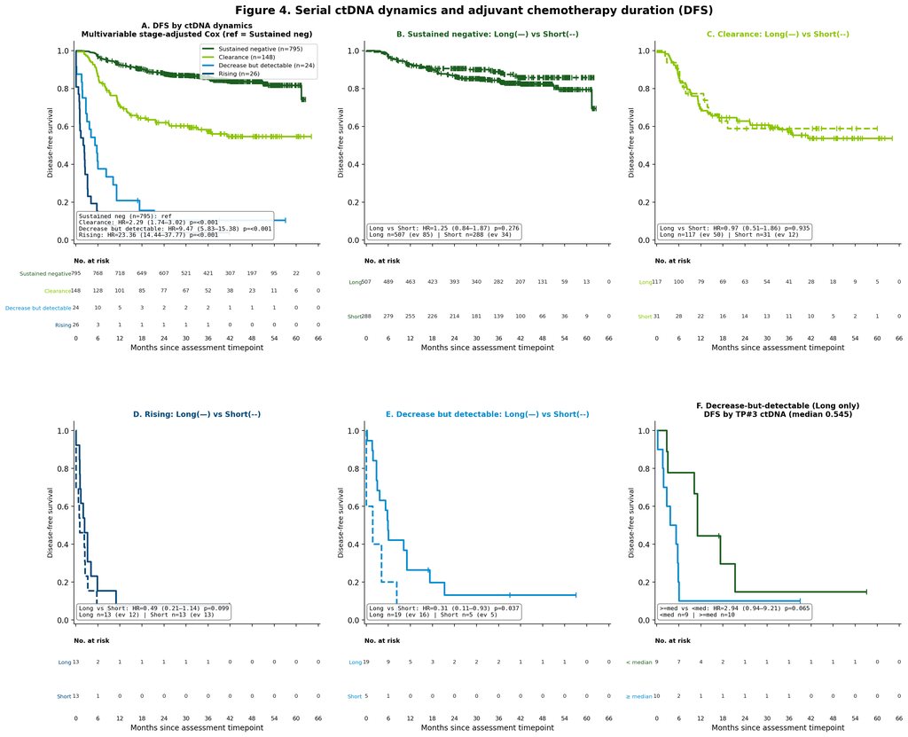

Figure 4 — hazard ratios (panels A–F)

| panel | comparison | HR | CI_low | CI_high | p | N |
| --- | --- | --- | --- | --- | --- | --- |
| A | Clearance vs Sustained neg (MV stage-adj) | 2.291 | 1.736 | 3.025 | 4.881776e-09 | 148 |
| A | Decrease but detectable vs Sustained neg (MV stage-adj) | 9.466 | 5.825 | 15.383 | 1.155976e-19 | 24 |
| A | Rising vs Sustained neg (MV stage-adj) | 23.356 | 14.444 | 37.767 | 8.638352e-38 | 26 |
| B | Sustained negative: Long vs Short | 1.250 | 0.836 | 1.868 | 2.762585e-01 | L507/S288 |
| C | Clearance: Long vs Short | 0.974 | 0.511 | 1.856 | 9.350230e-01 | L117/S31 |
| D | Rising: Long vs Short | 0.489 | 0.209 | 1.145 | 9.916490e-02 | L13/S13 |
| E | Decrease but detectable: Long vs Short | 0.314 | 0.106 | 0.932 | 3.685794e-02 | L19/S5 |
| F | Decrease (Long only): >=median vs <median TP#3 ctDNA | 2.936 | 0.935 | 9.214 | 6.501082e-02 | 19 |